# starter_pack_peru

We can repeat the analysis for Roads, which look a little different from housing and people:

```python
roads_zoom = subset_exposures_to_extent(entity_roads.exposures, extent_streetlevel)

for dist_threshold in distance_thresholds_to_test:
    _ = plot_exposures_within_threshold(haz_streetlevel, roads_zoom, dist_threshold, figsize=(4, 5))
```

```
2026-07-03 09:33:16,800 - climada.entity.exposures.base - INFO - Matching 17 exposures with 2094 centroids.
2026-07-03 09:33:16,807 - climada.util.coordinates - INFO - No exact centroid match found. Reprojecting coordinates to nearest neighbor closer than the threshold = 7.237582121888408e-05 degree
2026-07-03 09:33:16,811 - climada.util.coordinates - WARNING - Distance to closest centroid is greater than 0.000072 degree for 4 coordinates.
2026-07-03 09:33:17,304 - climada.entity.exposures.base - INFO - Matching 17 exposures with 2094 centroids.
2026-07-03 09:33:17,309 - climada.util.coordinates - INFO - No exact centroid match found. Reprojecting coordinates to nearest neighbor closer than the threshold = 0.0001 degree
2026-07-03 09:33:17,777 - climada.entity.exposures.base - INFO - Matching 17 exposures with 2094 centroids.
2026-07-03 09:33:17,780 - climada.util.coordinates - INFO - No exact centroid match found. Reprojecting coordinates to nearest neighbor closer than the threshold = 0.0002 degree
2026-07-03 09:33:18,256 - climada.entity.exposures.base - INFO - Matching 17 exposures with 2094 centroids.
2026-07-03 09:33:18,260 - climada.util.coordinates - INFO - No exact centroid match found. Reprojecting coordinates to nearest neighbor closer than the threshold = 0.0003 degree
2026-07-03 09:33:18,740 - climada.entity.exposures.base - INFO - Matching 17 exposures with 2094 centroids.
2026-07-03 09:33:18,745 - climada.util.coordinates - INFO - No exact centroid match found. Reprojecting coordinates to nearest neighbor closer than the threshold = 0.0004 degree
```

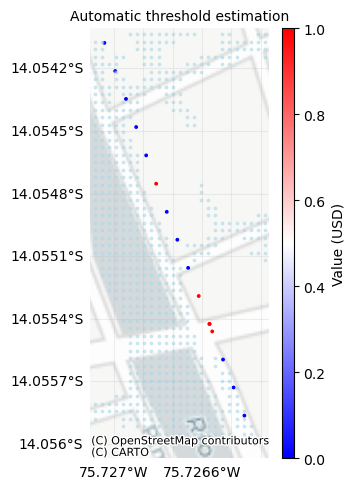

png

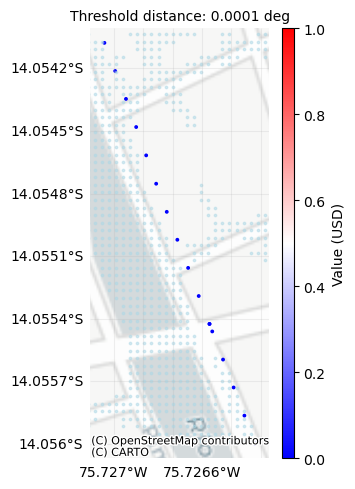

png

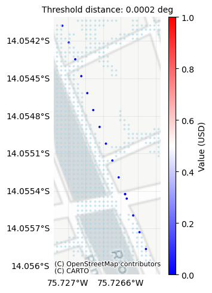

png

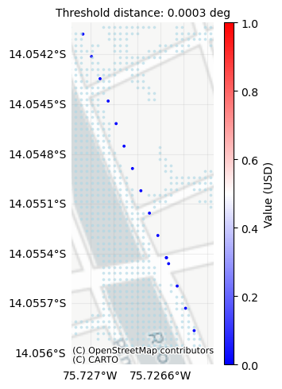

png

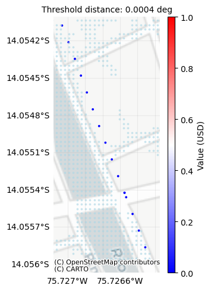

png

```python
dist_threshold = 0.0002

for entity in entity_list:
    entity.exposures.assign_centroids(hazard=haz, threshold=dist_threshold, overwrite=True)
```

```
2026-07-03 09:33:21,163 - climada.entity.exposures.base - INFO - Matching 107016 exposures with 282071 centroids.
2026-07-03 09:33:21,563 - climada.util.coordinates - INFO - No exact centroid match found. Reprojecting coordinates to nearest neighbor closer than the threshold = 0.0002 degree
2026-07-03 09:33:22,264 - climada.util.coordinates - WARNING - Distance to closest centroid is greater than 0.000200 degree for 99557 coordinates.
2026-07-03 09:33:22,274 - climada.entity.exposures.base - INFO - Matching 107016 exposures with 282071 centroids.
2026-07-03 09:33:22,656 - climada.util.coordinates - INFO - No exact centroid match found. Reprojecting coordinates to nearest neighbor closer than the threshold = 0.0002 degree
2026-07-03 09:33:23,343 - climada.util.coordinates - WARNING - Distance to closest centroid is greater than 0.000200 degree for 99557 coordinates.
2026-07-03 09:33:23,351 - climada.entity.exposures.base - INFO - Matching 18640 exposures with 282071 centroids.
2026-07-03 09:33:23,623 - climada.util.coordinates - INFO - No exact centroid match found. Reprojecting coordinates to nearest neighbor closer than the threshold = 0.0002 degree
2026-07-03 09:33:23,850 - climada.util.coordinates - WARNING - Distance to closest centroid is greater than 0.000200 degree for 17165 coordinates.
```

## 5.3 Calculate risk

With all these ingredients we can run risk calculations using CLIMADA’s `ImpactCalc` class.

In the code below we only run one impact function for one entity file, but please run the calculations for other Exposure types and impact functions. The code includes a method to assign a different impact function to the Exposures so that you can test out other impact functions.

```python
def change_entity_exposure_impf(entity, new_impf_id):
    new_gdf = copy.deepcopy(entity.exposures.gdf)
    new_gdf["impf_id"] = new_impf_id
    entity.exposures.set_gdf(new_gdf)
    return entity
```

```python
from climada.engine import ImpactCalc, ImpactFreqCurve

# The ImpactCalc class sets up the calculation
imp_calc_residences = ImpactCalc(
    exposures=entity_residences.exposures,
    impfset=entity_residences.impact_funcs,
    hazard=haz
)
# ...and its .impact method runs the calculation, creating an Impact object
imp_residences_economic = imp_calc_residences.impact(
    save_mat=True,          # Save the impact matrix (see below). This can be large, but we want it to explore some additional calculations
    assign_centroids=False  # Don't (re)assign centroids
)
```

```
2026-07-03 09:33:23,921 - climada.engine.impact_calc - INFO - Calculating impact for 29925 assets (>0) and 6 events.
```

```python
# And we can repeat this impact calculation for people and road exposures:

imp_calc_people = ImpactCalc(
    exposures=entity_people.exposures,
    impfset=entity_people.impact_funcs,
    hazard=haz
)
imp_people_affected = imp_calc_people.impact(
    save_mat=True,          # Save the impact matrix (see below)
    assign_centroids=False  # Don't (re)assign centroids
)

imp_calc_roads = ImpactCalc(
    exposures=entity_roads.exposures,
    impfset=entity_roads.impact_funcs,
    hazard=haz
)
imp_roads_economic = imp_calc_roads.impact(
    save_mat=True,          # Save the impact matrix (see below)
    assign_centroids=False  # Don't (re)assign centroids
)
```

```
2026-07-03 09:33:24,083 - climada.engine.impact_calc - INFO - Calculating impact for 17015 assets (>0) and 6 events.
2026-07-03 09:33:24,142 - climada.engine.impact_calc - INFO - Calculating impact for 6475 assets (>0) and 6 events.
```

The Impact object has properties and methods that support you in creating risk statistics.

At the core of it is the impact matrix, which is a sparse matrix with dimensions (number of events) x (number of exposure points). It gives the calculated impact of each event at each point of exposure.

We can print some of these properties, and plot event losses:

```python
import matplotlib.pyplot as plt

for imp, asset_name in zip([imp_residences_economic, imp_people_affected, imp_roads_economic], entity_names):
    print(f"Number of exposures: {len(imp.eai_exp)}")
    print(f"Number of events: {len(imp.event_id)}")
    print(f"Size of impact matrix: {imp.imp_mat.shape}")

    # Summing the impact across all exposed points gives us the total impact per event. This is calculated during the impact calculation and stored in the `.at_event` attribute.
    print("Total impact per event:")
    print([f'{event_name}: {impact:,.0f}' for event_name, impact in zip(imp.event_name, imp.at_event)])

    # Combining the event-wise impacts with the events' frequencies let us calculate the average annual loss (AAL). This is stored in the `.aal_agg` attribute.
    print("Average annual impact (AAI, or AAL) per event:")
    print(f"{imp.aai_agg:.2f}")

    # Plot this array as a bar chart
    plt.bar(imp.event_name, imp.at_event)
    plt.ylabel("Total impact")
    plt.title(f"Total impact per event: {asset_name}")
    plt.xticks(rotation=25, ha="right")
    plt.tight_layout()
    plt.show()
```

```
Number of exposures: 107016
Number of events: 6
Size of impact matrix: (6, 107016)
Total impact per event:
['Return period 10: 3,189,703', 'Return period 25: 19,007,911', 'Return period 50: 74,273,929', 'Return period 100: 179,308,134', 'Return period 200: 301,627,299', 'Return period 500: 524,835,116']
Average annual impact (AAI, or AAL) per event:
4165372.51
```

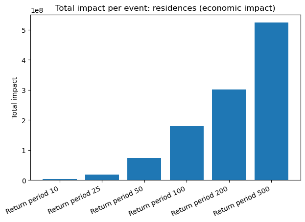

png

```
Number of exposures: 107016
Number of events: 6
Size of impact matrix: (6, 107016)
Total impact per event:
['Return period 10: 148', 'Return period 25: 509', 'Return period 50: 2,120', 'Return period 100: 6,067', 'Return period 200: 9,924', 'Return period 500: 17,188']
Average annual impact (AAI, or AAL) per event:
134.74
```

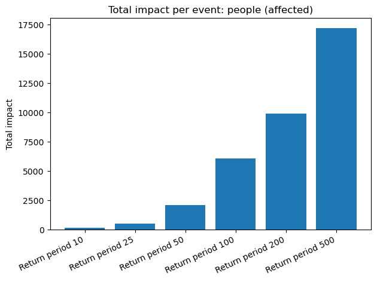

png

```
Number of exposures: 18640
Number of events: 6
Size of impact matrix: (6, 18640)
Total impact per event:
['Return period 10: 579,316', 'Return period 25: 1,062,769', 'Return period 50: 1,595,636', 'Return period 100: 2,165,116', 'Return period 200: 2,766,456', 'Return period 500: 3,859,235']
Average annual impact (AAI, or AAL) per event:
98814.14
```

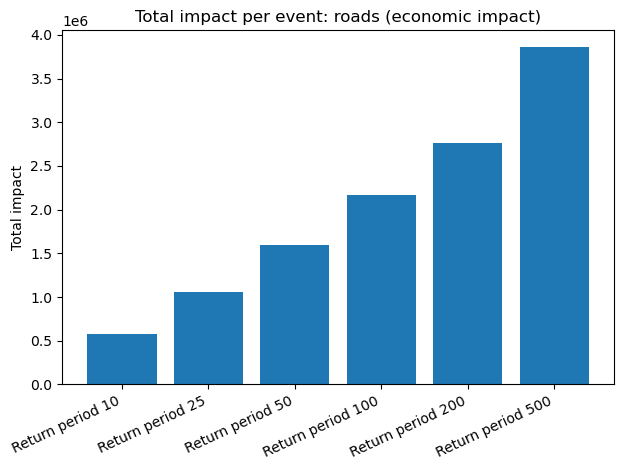

png

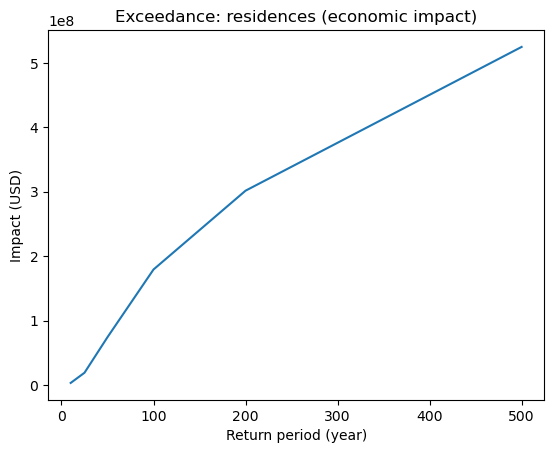

png

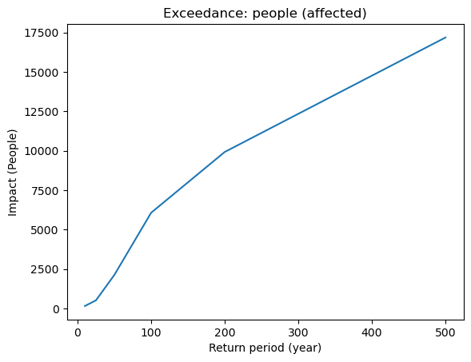

png

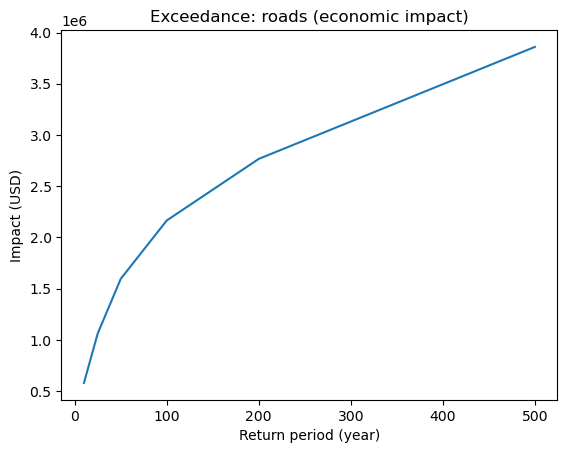

png

```python
# We can extract an exceedance curve, showing how total losses change with return periods
# This method returns a ImpactFreqCurve object, which can be plotted.

for imp, asset_name in zip([imp_residences_economic, imp_people_affected, imp_roads_economic], entity_names):
    exceedance_curve = imp.calc_freq_curve(return_per=HAZARD_RETURN_PERIODS)
    axis = exceedance_curve.plot()
    axis.set_title(f"Exceedance: {asset_name}")
```

[figure not shown]

png

[figure not shown]

png

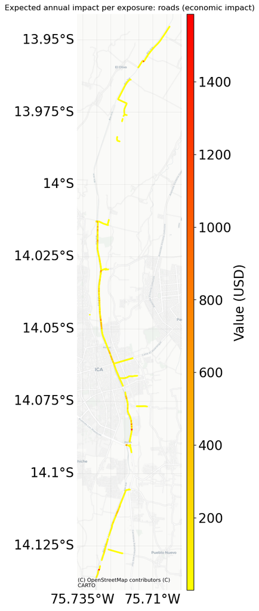

png

```python
import contextily as ctx

# We can map the average annual impact by individual exposure point:
for imp, asset_name in zip([imp_residences_economic, imp_people_affected, imp_roads_economic], entity_names):
    axis = imp.plot_basemap_eai_exposure(
        ignore_zero=True,                   # Don't plot locations with zero impacts
        pop_name=False,                     # Don't plot place names
        buffer=500,                         # Add spatial buffers to the map (in the CRS coordinate units)
        s=2,                                # The size of point markers on the plot
        zoom=14,                            # Level of detail to add to the basemap
        cmap="autumn_r",                    # Colour scheme to use for the points. See https://matplotlib.org/stable/tutorials/colors/colormaps.html for options.
        url=ctx.providers.CartoDB.Positron  # Basemap provider
    )
    axis.set_title(f"Expected annual impact per exposure: {asset_name}")

# Note: there are also methods to plot hexbin and raster plots (as with Exposures)
```

```python
from IPython.display import display

# Looking at the impact data across all events gives us the information about the impact per exposed point instead.
# Here we look at the results for residences, but you can change this for people or roads
imp = imp_residences_economic

# TODO zoom in for these plots

# Generate a GeoDataFrame of custom return period impacts for every exposure:
custom_return_periods = [20, 225]
local_exceedance, _, _ = imp.local_exceedance_impact(
    return_periods=custom_return_periods,
    method="interpolate",    # How to deal with interpolated and extrapolated impacts (default here is only interpolate)
    min_impact=0,            # Filter impacts below this value
    log_frequency=True,
    log_impact=True,
)
local_exceedance = local_exceedance.dropna()

print("Exposure level return period exceedance:")
display(local_exceedance.head())

# Plot impacts at custom return periods
axis, _ = imp.plot_rp_imp(
    return_periods=custom_return_periods,
    log10_scale=False,
    figsize=(10, 6),
    kwargs_local_exceedance_impact=None,
)
```

```
2026-07-03 09:33:29,525 - climada.engine.impact - INFO - Computing exceedance impact map for return periods: [20, 225]
Exposure level return period exceedance:
```

|  | geometry | 20 | 225 |
| --- | --- | --- | --- |
| 12575 | POINT (-75.72137 -14.06961) | 110640.910689 | 236690.552242 |
| 17493 | POINT (-75.71947 -14.07612) | 40038.391744 | 75334.180822 |
| 17495 | POINT (-75.71947 -14.07584) | 74169.197202 | 90547.162959 |
| 17496 | POINT (-75.71947 -14.07569) | 65574.135881 | 84459.529912 |
| 17497 | POINT (-75.71946 -14.07555) | 24847.766077 | 71021.523337 |

```
2026-07-03 09:33:30,490 - climada.engine.impact - INFO - Some errors in the previous calculation of local exceedance impacts have been corrected, see Impact.local_exceedance_impact. To reproduce data with the previous calculation, use CLIMADA v5.0.0 or less.
2026-07-03 09:33:30,490 - climada.engine.impact - INFO - Computing exceedance impact map for return periods: [20, 225]
```

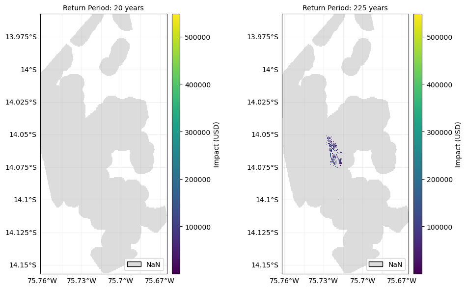

png

## 5.4 Assets affected

What if we want to count the number of assets affected or the number damaged according to a particular thresholds? CLIMADA offers a couple of ways to do this.

This section only looks at the Residential exposure, but you can change which entity file is analyzed in the code here.

```python
entity = entity_residences
```

```python
# To get a broad sense of the value of exposures that are affected by any hazard (across all events), the Exposures'
# `affected_total_value` attribute is helpful:
affected_value = entity.exposures.affected_total_value(
    hazard=haz,
    threshold_affected=0,
    overwrite_assigned_centroids=False
)
affected_households = affected_value / RESIDENCE_VALUE_USD
print(f"Total value of affected exposures: {affected_value:,.0f} USD")
print(f"Total number of affected households: {affected_households:,.0f}")
```

```
2026-07-03 09:33:41,780 - climada.entity.exposures.base - INFO - Exposures matching centroids already found for FL
Total value of affected exposures: 954,595,291 USD
Total number of affected households: 9,801
```

```python
from climada.entity import ImpactFunc, ImpactFuncSet
# But to make this probabilistic – that is, to get the number of affected houses at different return periods,
# or to get an average annual value – we need to run another impact calculation, this time with a step function as the
# impact function.

# We can use inbuilt functionality to create a stepped impact function
# (Note that this is a bit redundant when we already have an step function in our impact function set,)
# (but you won't always have this, and creating custom step functions is very useful)
# First choose a flood depth that counts as affected:
affected_threshold = 0.22    # This is about the water depth where we model 20% impact with this uncalibrated impact function

# Create an impact function
affected_step_impf = ImpactFunc.from_step_impf(
    intensity=(0, affected_threshold, 2),
    haz_type="FL",
    mdd=(0, 1),
    paa=(1, 1),
    impf_id=101
)

# Plot the impact function
affected_step_impf.plot()

# Add it to a new ImpactFuncSet for use in a risk calculation
affected_impfset = ImpactFuncSet([affected_step_impf])

# We could do this next calculation with the affected value of houses, but let's divide our exposure by the value of an average house to get the number of affected households instead.
entity_households = copy.deepcopy(entity)
new_gdf = entity_households.exposures.gdf
new_gdf["value"] = new_gdf["value"] / RESIDENCE_VALUE_USD
entity_households.exposures.set_gdf(new_gdf)
entity_households.exposures.value_unit = "Number of households"

# And create a new ImpactCalc and Impact object
imp_calc_affected = ImpactCalc(
    exposures=entity_households.exposures,
    impfset=affected_impfset,
    hazard=haz
)
imp_affected = imp_calc_affected.impact(
    save_mat=True,          # Save the impact matrix (see below). This can be large, but we want it to explore some additional calculations
    assign_centroids=False  # Don't (re)assign centroids
)

# Now we can get probabilistic information on the average annual affected households and the household affected by return period
aal_affected_households = imp_affected.aai_agg
aal_affected_value = aal_affected_households * RESIDENCE_VALUE_USD
print(f"Average annual number of affected households: {aal_affected_households:,.0f}")
print(f"Average annual value of affected housing: {aal_affected_value:,.0f} USD")

# And we can extract an affected exceedance curve in the same way
affected_freq_curve = imp_affected.calc_freq_curve(return_per=HAZARD_RETURN_PERIODS)
axis = affected_freq_curve.plot()
_ = axis.set_title("Exceedance curve: number of houses affected")
_ = axis.set_ylabel("Number of affected households")

# And plot the expected value of affected households at custom return periods
axis_plot = imp_affected.plot_basemap_eai_exposure(
    ignore_zero=True,                   # Don't plot locations with zero impacts
    pop_name=False,                     # Don't plot place names
    buffer=500,                         # Add spatial buffers to the map (in the CRS coordinate units)
    s=2,                                # The size of point markers on the plot
    zoom=14,                            # Level of detail to add to the basemap
    url=ctx.providers.CartoDB.Positron  # Basemap provider
)
_ = axis_plot.set_title("Average annual number of affected households")
```

```
2026-07-03 09:33:41,879 - climada.engine.impact_calc - INFO - Calculating impact for 29925 assets (>0) and 6 events.
Average annual number of affected households: 67
Average annual value of affected housing: 6,499,644 USD
```

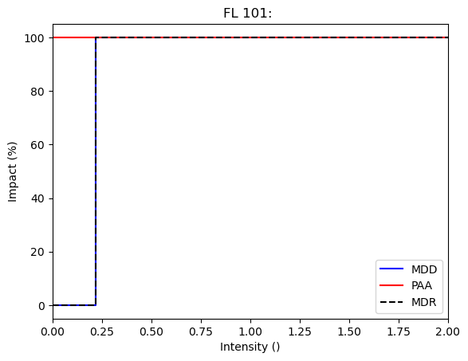

png

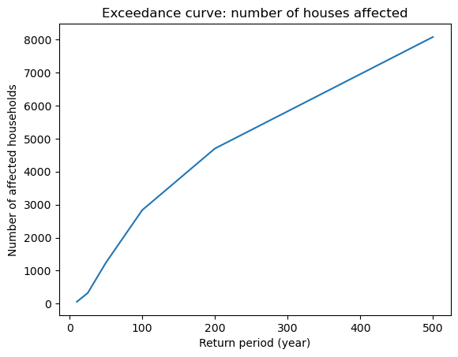

png

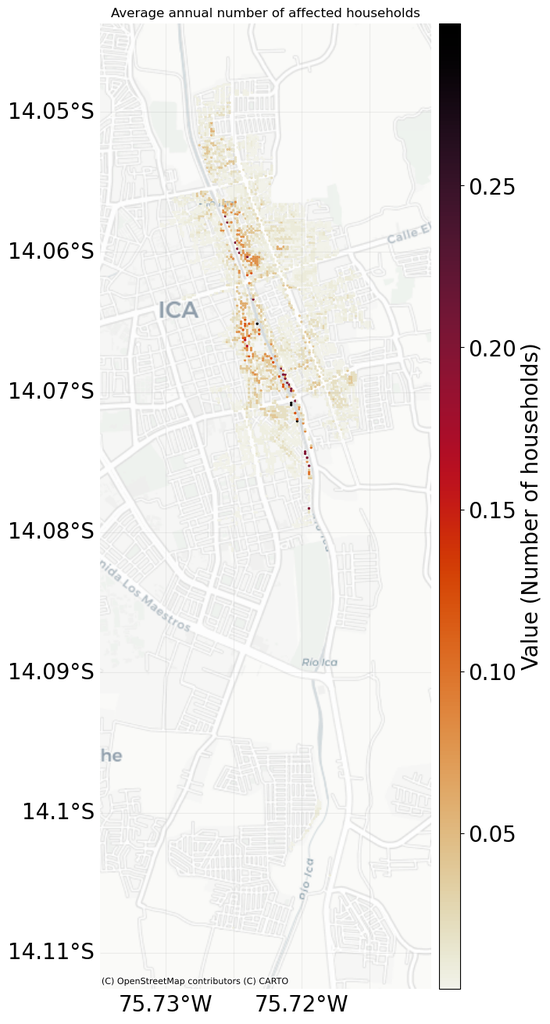

png

# 6 Observations

The Peruvian government maintains a database of disaster impact observations. In this notebook we use an extract from the database to identify past events that affected Ica.

The extract in the observations_raw.csv file has already been processed (to reduce the size, selecting Ica events) and reformatted (to add English column names).

```python
from pathlib import Path

# -----------------------------------------------
# Set up paths to data
# -----------------------------------------------

OBSERVATIONS_DIR = "../data/observations/"
OBSERVATIONS_FILE = "observations_raw.csv"
observations_filepath = Path(OBSERVATIONS_DIR) / OBSERVATIONS_FILE
```

```python
import pandas as pd
import numpy as np
from IPython.display import display

# -----------------------------------------------
# Read and reformat the raw observations
# -----------------------------------------------

obs = pd.read_csv(observations_filepath)
obs = obs.rename(columns={
    "EMERGENCY CODE (CÓDIGO DE EMERGENCIA-SINPAD)": "code",
    "DATE OF THE EMERGENCY (FECHA  DE LA EMER)": "date",
    "Year (AÑO)": "year",
    "Month (MES)": "month",
    "COD. DISTRITO": "district_code",
    "Department - Admin 1 (DPTO.)": "department",
    "Province - Admin 2 (PROV.)": "province",
    "District - Admin 3 (DIST.)": "district",
    "Deaths (FALLECIDOS)": "deaths",
    "Missing (DESAPARECIDOS)": "missing",
    "Injured (HERIDOS)": "injured",
    "VICTIMS (DAMNIFICADOS)": "victims",
    "AFFECTED (AFECTADOS)": "affected",
    "HOMES DESTROYED (VIVIENDAS DESTRUIDAS)": "homes_destroyed",
    "AFFECTED HOMES (VIVIENDAS AFECTADAS)": "homes_affected",
})
# Subset to the columns we need:
obs = obs[[
    "date", "year", "month", "district", "homes_destroyed", "homes_affected", "victims", "affected"
]]
obs["affected_or_destroyed"] = obs["homes_destroyed"] + obs["homes_affected"]
obs["victims_or_affected"] = obs["victims"] + obs["affected"]


# -----------------------------------------------
# Filter to modelled districts
# -----------------------------------------------

# A manual check of the overlap of Ica districts and the study area covered by the hazard show these Ica districts to be
# outside of the hazard area. Therefore we can't model their losses and they should be dropped from the observations.
districts_to_drop = [
    "SAN JOSÉ DE LOS MOLINOS",
    "GUADALUPE",
    "PACHACUTEC",
    "SANTIAGO",
    "OCUCAJE"
]
obs = obs[~obs["district"].isin(districts_to_drop)]
print("Relevant observations:")
display(obs)
```

```
Relevant observations:
```

|  | date | year | month | district | homes_destroyed | homes_affected | victims | affected | affected_or_destroyed | victims_or_affected |
| --- | --- | --- | --- | --- | --- | --- | --- | --- | --- | --- |
| 0 | 12/12/2003 | 2003 | Diciembre | ICA | 1 | 3 | 11 | 13 | 4 | 24 |
| 1 | 21/01/2004 | 2004 | Enero | ICA | 0 | 9 | 0 | 45 | 9 | 45 |
| 2 | 07/11/2004 | 2004 | Noviembre | PARCONA | 0 | 2 | 0 | 13 | 2 | 13 |
| 3 | 05/11/2005 | 2005 | Noviembre | ICA | 0 | 2 | 0 | 6 | 2 | 6 |
| 4 | 11/01/2005 | 2005 | Enero | SALAS | 0 | 3 | 0 | 10 | 3 | 10 |
| 5 | 18/03/2006 | 2006 | Marzo | ICA | 0 | 3 | 0 | 0 | 3 | 0 |
| 6 | 22/12/2007 | 2007 | Diciembre | ICA | 0 | 5 | 0 | 0 | 5 | 0 |
| 7 | 02/04/2007 | 2007 | Abril | LOS AQUIJES | 0 | 6 | 0 | 17 | 6 | 17 |
| 9 | 05/06/2008 | 2008 | Junio | ICA | 5 | 1 | 22 | 1 | 6 | 23 |
| 10 | 08/02/2011 | 2011 | Febrero | LOS AQUIJES | 0 | 69 | 0 | 348 | 69 | 348 |
| 13 | 07/02/2012 | 2012 | Febrero | LOS AQUIJES | 0 | 0 | 0 | 0 | 0 | 0 |
| 16 | 28/02/2013 | 2013 | Febrero | SAN JUAN BAUTISTA | 0 | 0 | 0 | 0 | 0 | 0 |
| 19 | 28/03/2014 | 2014 | Marzo | ICA | 0 | 0 | 6 | 0 | 0 | 6 |
| 20 | 10/01/2017 | 2017 | Enero | ICA | 0 | 3540 | 74 | 17700 | 3540 | 17774 |
| 21 | 18/01/2017 | 2017 | Enero | ICA | 1 | 0 | 3 | 0 | 1 | 3 |
| 22 | 24/01/2017 | 2017 | Enero | LA TINGUIÑA | 133 | 845 | 636 | 4225 | 978 | 4861 |

```python
# -------------------------------------------------
# Group events in time and aggregate over districts
# -------------------------------------------------

# Use the date column to identify events that happen within 60 days of each other: we classify these as the same event.
# This is a subjective choice!
grouping_window_days = 60
obs["date"] = pd.to_datetime(obs["date"], format="%d/%m/%Y")
obs = obs.sort_values("date").reset_index(drop=True)
obs["event_id"] = (obs["date"].diff().dt.days > grouping_window_days).cumsum()

# Group the events and sum them over districts to get total impacts
obs = obs.drop(columns=["district", "date"]).groupby(["event_id"]).agg({
    "homes_destroyed": "sum",
    "homes_affected": "sum",
    "affected_or_destroyed": "sum",
    "victims": "sum",
    "affected": "sum",
    "victims_or_affected": "sum",
    "year": "first",
    "month": "first"
}).reset_index()

print("Aggregated observations:")
display(obs)
```

```
Aggregated observations:
```

|  | event_id | homes_destroyed | homes_affected | affected_or_destroyed | victims | affected | victims_or_affected | year | month |
| --- | --- | --- | --- | --- | --- | --- | --- | --- | --- |
| 0 | 0 | 1 | 12 | 13 | 11 | 58 | 69 | 2003 | Diciembre |
| 1 | 1 | 0 | 2 | 2 | 0 | 13 | 13 | 2004 | Noviembre |
| 2 | 2 | 0 | 3 | 3 | 0 | 10 | 10 | 2005 | Enero |
| 3 | 3 | 0 | 2 | 2 | 0 | 6 | 6 | 2005 | Noviembre |
| 4 | 4 | 0 | 3 | 3 | 0 | 0 | 0 | 2006 | Marzo |
| 5 | 5 | 0 | 6 | 6 | 0 | 17 | 17 | 2007 | Abril |
| 6 | 6 | 0 | 5 | 5 | 0 | 0 | 0 | 2007 | Diciembre |
| 7 | 7 | 5 | 1 | 6 | 22 | 1 | 23 | 2008 | Junio |
| 8 | 8 | 0 | 69 | 69 | 0 | 348 | 348 | 2011 | Febrero |
| 9 | 9 | 0 | 0 | 0 | 0 | 0 | 0 | 2012 | Febrero |
| 10 | 10 | 0 | 0 | 0 | 0 | 0 | 0 | 2013 | Febrero |
| 11 | 11 | 0 | 0 | 0 | 6 | 0 | 6 | 2014 | Marzo |
| 12 | 12 | 134 | 4385 | 4519 | 713 | 21925 | 22638 | 2017 | Enero |

```python
# -----------------------------------------------
# Drop small events
# -----------------------------------------------

# We choose to filter to events with at least 10 affected or destroyed homes to focus on more significant events
# This avoids issues with underreporting of very small events, and handling small events that may only be included in
# the database because of much larger impacts in neighbouring regions.
obs = obs[obs["affected_or_destroyed"] >= 10].reset_index(drop=True)
print("Filtered observations:")
display(obs)
```

```
Filtered observations:
```

|  | event_id | homes_destroyed | homes_affected | affected_or_destroyed | victims | affected | victims_or_affected | year | month |
| --- | --- | --- | --- | --- | --- | --- | --- | --- | --- |
| 0 | 0 | 1 | 12 | 13 | 11 | 58 | 69 | 2003 | Diciembre |
| 1 | 8 | 0 | 69 | 69 | 0 | 348 | 348 | 2011 | Febrero |
| 2 | 12 | 134 | 4385 | 4519 | 713 | 21925 | 22638 | 2017 | Enero |

### 6.0.1 Adjust for historic growth

The observation data we have reflects impacts in past years. Since then the population of Ica and its socioeconomic conditions have changed. We would like to adjust the historic observations to reflect what the impacts would look like if they happened today.

In this calculation the adjustment is very simple: we scale the number of houses by the national change in population since the event. A more advanced adjustment would use Ica-specific population data and might also take into account changes in average household size or even spatial changes in housing.

```python
SOCIOECONOMIC_DIR = "../data/socioeconomic_change/"
POP_CHANGE_FILE = "population_change_historic.csv"
PRESENT_YEAR = 2025

df_pop_change = pd.read_csv(Path(SOCIOECONOMIC_DIR) / POP_CHANGE_FILE)
df_pop_change['scale'] = df_pop_change['pop_change'] + 1

# Define a method that calculates the adustment we need to apply between any two years
def population_ratio(year_from, year_to):
    assert year_from <= year_to, "year_from must be less than or equal to year_to"
    assert year_from in df_pop_change["year"].values, f"year_from {year_from} not found in population change data"
    assert year_to in df_pop_change["year"].values, f"year_to {year_to} not found in population change data"
    df_filtered = df_pop_change[(df_pop_change["year"] >= year_from) & (df_pop_change["year"] <= year_to)]
    ratio = df_filtered["scale"].prod()
    return ratio

obs["population_ratio"] = obs.apply(lambda row: population_ratio(row["year"], PRESENT_YEAR), axis=1)

for col in ["homes_affected", "homes_destroyed", "affected_or_destroyed", "victims", "affected", "victims_or_affected"]:
    obs[f"{col}_present"] = obs[col] * obs["population_ratio"]

obs.drop(columns=["population_ratio", "homes_affected", "homes_destroyed", "affected_or_destroyed", "victims", "affected", "victims_or_affected"], inplace=True)
display(display(obs.style.format({
    "homes_affected_present": "{:,.1f}",
    "homes_destroyed_present": "{:,.1f}",
    "affected_or_destroyed_present": "{:,.1f}",
    "victims_present": "{:,.1f}",
    "affected_present": "{:,.1f}",
    "victims_or_affected_present": "{:,.1f}"
})))
```

|  | event_id | year | month | homes_affected_present | homes_destroyed_present | affected_or_destroyed_present | victims_present | affected_present | victims_or_affected_present |
| --- | --- | --- | --- | --- | --- | --- | --- | --- | --- |
| 0 | 0 | 2003 | Diciembre | 15.2 | 1.3 | 16.4 | 13.9 | 73.4 | 87.3 |
| 1 | 8 | 2011 | Febrero | 82.1 | 0.0 | 82.1 | 0.0 | 413.9 | 413.9 |
| 2 | 12 | 2017 | Enero | 4,897.4 | 149.7 | 5,047.1 | 796.3 | 24,487.1 | 25,283.5 |

```
None
```

### 6.0.2 Estimate historic losses

From the 2017 disaster recovery reports, we have information on the post-disaster government expenditure for housing reconstruction. The costs include costs for repairing damaged houses, rebuilding destroyed houses, and purchasing land a building new houses for houses that were deemed to be at high risk of future flooding. We can use this information to rank their severity

Note: this is not the full economic cost of losses, this is what the government spent.

```python
RECOVERY_COSTS_USD = {
    'affected': 4260,   # Cost of rebuilding a damaged home, including improvements to resilience
    'destroyed': 6200,  # Cost of replacing a home, with improved standard of building materials
    'resettled': 17000  # Cost of buying new land and building a new home for buildings in high risk areas.
                        # (We don't have information on the criteria for this or the number of homes that qualified in past events).
}

obs["recovery_cost_usd"] = obs["homes_affected_present"] * RECOVERY_COSTS_USD['affected'] + obs["homes_destroyed_present"] * RECOVERY_COSTS_USD['destroyed']
display(obs.style.format({
    "homes_affected_present": "{:,.1f}",
    "homes_destroyed_present": "{:,.1f}",
    "affected_or_destroyed_present": "{:,.1f}",
    "recovery_cost_usd": "${:,.0f}",
    "victims_present": "{:,.1f}",
    "affected_present": "{:,.1f}",
    "victims_or_affected_present": "{:,.1f}"
}))
```

|  | event_id | year | month | homes_affected_present | homes_destroyed_present | affected_or_destroyed_present | victims_present | affected_present | victims_or_affected_present | recovery_cost_usd |
| --- | --- | --- | --- | --- | --- | --- | --- | --- | --- | --- |
| 0 | 0 | 2003 | Diciembre | 15.2 | 1.3 | 16.4 | 13.9 | 73.4 | 87.3 | $72,494 |
| 1 | 8 | 2011 | Febrero | 82.1 | 0.0 | 82.1 | 0.0 | 413.9 | 413.9 | $349,611 |
| 2 | 12 | 2017 | Enero | 4,897.4 | 149.7 | 5,047.1 | 796.3 | 24,487.1 | 25,283.5 | $21,790,936 |

### 6.0.3 Estimate observation return periods

Since our flood hazard data is provided by return period, our observations need return periods in order for us to be able to compare modelled losses.

Our observational dataset covers 18 years of historic observations (2003-2020). Without more detailed historic information, we assume the 18 years of historic data represent the present day climate, and that we can assign return periods based on this (ranked by estimated recovery cost).

However, for the most severe event, the 2017 floods, we have media reports and analyses from the time that give return period estimates for its intensity, and we will use these estimates instead. There have been many different estimates of return periods, or stating that this was the “most severe event since X”, and most of them refer to the national impacts rather than just Ica. Taking these into account we are estimating a return period of 92 years for the event, as this was the most severe El Niño since 1925.

However it is also very possible that this is higher or lower – adjust the parameter in the following code and see how this affects the calibration.

```python
N_YEARS_OBSERVATIONS = 18
RETURN_PERIOD_2017 = 92

# Sort by event severity
obs = obs.sort_values("recovery_cost_usd", ascending=False).reset_index(drop=True)

# Assign a rank
obs["rank"] = np.arange(1, len(obs) + 1)

# Assign a return period based on the rank (for 18 years we get RPs 1/18, 2/18 = 1/9, 3/18 = 1/6, ...)
obs["rp"] = N_YEARS_OBSERVATIONS / obs["rank"]

# ...except for the most severe event where we have better return period information from the literature
obs.iloc[0, obs.columns.get_loc("rp")] = RETURN_PERIOD_2017

# Index by return period
obs = obs[[
        "rp",
        "homes_affected_present",
        "homes_destroyed_present",
        "affected_or_destroyed_present",
        "recovery_cost_usd",
        "victims_present",
        "affected_present",
        "victims_or_affected_present"
    ]].set_index("rp")
```

```python
# Write outputs to file

obs_residential = obs[["homes_affected_present", "homes_destroyed_present", "affected_or_destroyed_present", "recovery_cost_usd"]]
out_filepath_residential = Path(OBSERVATIONS_DIR) / "observations_by_rp_residential.csv"
obs_residential.to_csv(out_filepath_residential)

print("Output: residential impacts by return period")
display(obs_residential.style.format({
    "homes_affected_present": "{:,.1f}",
    "homes_destroyed_present": "{:,.1f}",
    "affected_or_destroyed_present": "{:,.1f}",
    "recovery_cost_usd": "${:,.0f}"
}))

obs_people = obs[["victims_present", "affected_present", "victims_or_affected_present"]]
out_filepath_people = Path(OBSERVATIONS_DIR) / "observations_by_rp_people.csv"
obs_people.to_csv(out_filepath_people)

print("Output: people impacts by return period")
display(obs_people.style.format({
    "victims_present": "{:,.1f}",
    "affected_present": "{:,.1f}",
    "victims_or_affected_present": "{:,.1f}"
}))
```

```
Output: residential impacts by return period
```

| rp | homes_affected_present | homes_destroyed_present | affected_or_destroyed_present | recovery_cost_usd |
| --- | --- | --- | --- | --- |
| 92.000000 | 4,897.4 | 149.7 | 5,047.1 | $21,790,936 |
| 9.000000 | 82.1 | 0.0 | 82.1 | $349,611 |
| 6.000000 | 15.2 | 1.3 | 16.4 | $72,494 |

```
Output: people impacts by return period
```

| rp | victims_present | affected_present | victims_or_affected_present |
| --- | --- | --- | --- |
| 92.000000 | 796.3 | 24,487.1 | 25,283.5 |
| 9.000000 | 0.0 | 413.9 | 413.9 |
| 6.000000 | 13.9 | 73.4 | 87.3 |

# 7 Calibration: Residential

## 7.1 Overview

Calibration is often the trickiest part of any risk analysis. The goal of a CLIMADA calibration is to choose an impact function (or functions) that can best reproduce observations from previous events plus any other risk data you have.

We recommend always calibrating your risk model, even if you’ve had success with a particular impact function in the past. This is because

- Impact functions from the literature were almost always designed for different hazard models, different exposure data, and different contexts. They aren’t transferrable to new contexts right out of the box.
- Impact functions change a lot with the resolution of your data.
- There are often biases or in your particular hazard or exposure datasets.
- Each study has its own context: there are always unmodelled, local conditions that can affect impacts.

In general calibrations need to be done for every combination of hazard type and exposure type that you are modelling. However, you will often find that one calibration can inform others – e.g. if you don’t have many observations on damages to businesses in your study area, but you have information on damages to housing, and you know that your first-guess impact functions needed to be adjusted down, it’s reasonable to assume you’ll want to make a similar adjustment to the first-guess impact function for businesses.

Calibrations are usually done by one of

- **Manual calibration:** taking a first-guess impact function and manually adjusting it, repeating the risk calculation, comparing it to your observations, and repeating this until you are satisfied with the outputs.
- **Automated calibration:** specifying a family of impact functions, and using software to find the ‘best’ impact function within that family, according to some cost function that you specify.
- **Some combination of the both!** Where you get a sense of the kind of impact functions that work in your study, and then refine.

The approach that works best for you will depend on the number of observations that you’re fitting to, other constraints in what you consider to be an acceptable solution, the complexity of code that you’re prepared to write, and the time you have available. With approach (2) there is no limit to the complexity of algorithms you can design to search parameter spaces and optimise within constraints. See for example the new [Calibration module](https://climada-python.readthedocs.io/en/v6.1.0/user-guide/climada_util_calibrate.html) within CLIMADA, designed (for now) for calibrations where you are modelling a set of events where each has an observed loss.

**Tips:**

- Before you start calibrating get an understanding of your data. Ask yourself some of the following:
  - What is the rough shape of the impact function you are creating? Do impacts increase slowly or quickly with the hazard? What would the maximum impact be? What shape does the curve take?
  - In your model, what range of hazard value intensities affect the assets that you’re modelling? Your function should be defined across this range. (Check in the data – you are creating an impact function for the hazard that you have, not the hazard that you imagine.)
  - Are your losses driven by small impacts at lots of locations, or large impacts at a few locations? This will tell you which part of the curve to focus on.
  - Are historical losses more from large, rare events, or from more frequent events that occur e.g. every few years? This will tell you which events to focus on getting right.
  - What functions and functional forms have been used elsewhere in the literature and are they appropriate?
- The impact of zero hazard should usually be zero. If this is not the case (e.g. with temperature or drought data), we recommend transforming or masking the hazard (e.g. setting all values to zero below some threshold at which impacts start) so that 0 hazard has zero impact. This greatly speeds up the calculations and avoids unexpected bugs.
- Make sure that you are calculating something represented by your summary statistics, or something that is close. For example:
  - Make sure the area you are modelling matches the area that your observations apply to (Ica is both a city and a Departement in Peru!).
  - Make sure the hazard data represents the processes you care about (a river flood model will struggle to reproduce flash flood losses, a drought model will struggle to reproduce heatwave losses).
- In some calibrations you will want to go beyond just the impact function, and will decide to adjust other parts of the risk calculation. For example:
  - You may want to apply bias corrections to the hazard data (e.g. corrections to flood data based on gauge histories, corrections to rainfall intensities based on an observational dataset)
  - If you are consistently getting high or low losses, check if your exposure values could be biased low (e.g. sometimes building replacement costs are more than the building value (but less than the value of the building + land, take note of what your value date represents!)). There may be a reason to scale the values of Exposures
  - You may have knowledge about something the model represents poorly: e.g. an area that is well-defended against floods and which you may choose to mask from the hazard, or a new neighborhood or piece of infrastructure not in the Exposure data

### 7.1.1 Automated calibration to multiple observations

In this notebook we explore simple parameter search routines designed to help choose appropriate impact functions for housing impacts.

In this calculation, we will

- Read in and visualize the individual components of risk
- Write reusable methods to run the risk calculation and to compare the results to the observations
- Define a cost function to quantify how well the model is able to reproduce observations
- Write an optimization routine that tries to minimise this cost function over a family of impact functions. We do this for
  - Affected housing (calibrating a step function)
  - Destroyed housing (calibrating a step function)
  - Recovery costs (Adjusting an existing loss curve)

```python
from pathlib import Path

# Set up paths to data
ENTITY_DIR = "../data/entity_files_uncalibrated/"
ENTITY_FILE = "ICA_PERU_Entity_Floods_Residential.xlsx"
entity_filepath = Path(ENTITY_DIR) / ENTITY_FILE

CALIBRATED_ENTITY_DIR = "../data/entity_files_calibrated/"
CALIBRATED_ENTITY_FILE = "ICA_PERU_Entity_Floods_Residential_calibrated.xlsx"
calibrated_entity_filepath = Path(CALIBRATED_ENTITY_DIR) / CALIBRATED_ENTITY_FILE

HAZARD_DIR = "../data/hazard/"
HAZARD_FILES = ["tr10_h_max_61200_4326.tif", "tr25_h_max_61200_4326.tif", "tr50_h_max_61200_4326.tif", "tr100_h_max_61200_4326.tif", "tr200_h_max_61200_4326.tif", "tr500_h_max_72000_4326.tif"]
haz_filepaths = [Path(HAZARD_DIR) / filename for filename in HAZARD_FILES]

OBSERVATIONS_DIR = "../data/observations/"
OBSERVATIONS_FILE = "observations_by_rp_residential.csv"
observations_filepath = Path(OBSERVATIONS_DIR) / OBSERVATIONS_FILE
```

## 7.2 Load the components of risk

During the calibration we will be running risk calculations and plotting outputs repeatedly. To do this, we wrap the functionality of the central loop in reusable methods.

### 7.2.1 Load the Entity file

```python
import copy
from climada.entity import Entity

impf_column = "impf_FL"   # Impact function column in the assets table
impf_id_loss = 101        # ID of the impact function for economic loss that we're calibrating
impf_id_affected = 102    # ID of the impact function for affected homes that we're calibrating
impf_id_destroyed = 103   # ID of the impact function for destroyed homes that we're calibrating

# Read the Entity file
def read_entity(path, value_column):
    entity = Entity.from_excel(path)

    # In the calibration, we calibrate against _number of buildings_ that are affected or destroyed
    # In the Entity file the 'value' column contains building value information in USD, and the e.g. 'housing_count'
    # column contains the number of buildings. So we rename the columns so that the 'value' column contains the
    # information we want.
    if value_column == 'value':
        return entity
    new_gdf = entity.exposures.gdf.copy()
    new_gdf["value"] = new_gdf[value_column]
    entity.exposures.set_gdf(new_gdf)
    return entity

# Read the Entity file for USD value
entity_usd = read_entity(entity_filepath, value_column='value')
entity_usd.exposures.ref_year = 2025
entity_usd.exposures.value_unit = "USD"
entity_usd.exposures.description = "Housing value"

# Read the Entity file for housing count
entity_count = read_entity(entity_filepath, value_column='housing_count')
entity_count.exposures.ref_year = 2025
entity_count.exposures.value_unit = "number of houses"
entity_count.exposures.description = "Number of houses"
```

#### 7.2.1.1 Plot exposures

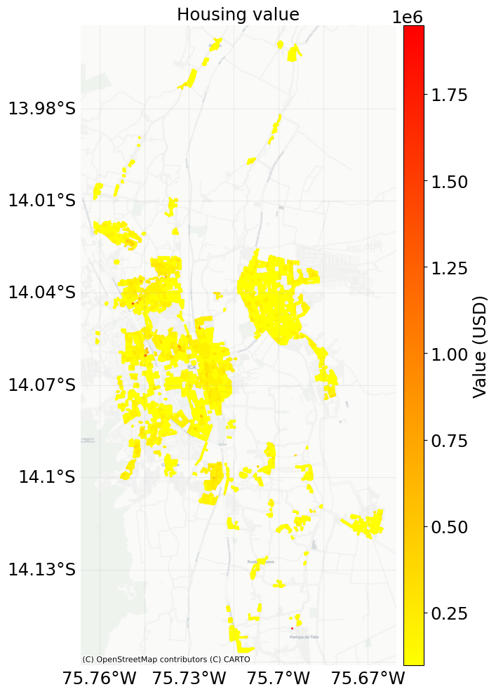

png

```python
# Plot the exposures
_ = entity_usd.exposures.plot_basemap(
        ignore_zero=True,       # Whether to plot points with zero value
        buffer=500,              # Add a buffer around the points to show a larger map region (measured in meters)
        s=1,                     # The size of point markers on the plot
        zoom=14,                 # The detail level of the map. 6 is good for a large country. 8 is good for a state or region. 13 for a city. 15 for a municipality.
        pop_name=False,          # Add the names of populated places to the map – often not necessary when you have a basemap
        vmax=None,               # Set the maximum value for the colour scale – use this if you want a consistent scheme across multiple plots.
        cmap="autumn_r",         # Colour scheme to use for the points. See https://matplotlib.org/stable/tutorials/colors/colormaps.html for options.
        figsize=(8, 10)         # Dimensions of the output figure
    )
```

#### 7.2.1.2 Plot impact functions

There are a few ways to approach a calibration like this, depending on the statistics you want to produce and the purposes of the calibration.

Our approach is going to look at three flood damage curves, each describing a different risk metric: - A depth-damage curve that estimates the % loss at a point of exposure. We want to calibrate this to give realistic losses, but we don’t have loss numbers for losses in the study area, so this has to be calibrated through other curves. - An ‘affected’ step-function. This gives the threshold at which a household is considered to be affected by the flood - A ‘destroyed’ step-function. This gives the threshold at which a household is considered to be destroyed, and must be rebuilt.

Note: a simpler calibration might just calibrate the second and third of the above impact functions: they are independent and can be used for recovery cost estimations by themselves. However, given a few assumptions, we can attempt all three.

We have first-guess versions of these three impact functions in the Entity file:

```python
# Plot the impact functions
_ = entity_usd.impact_funcs.plot()
```

[output not shown]

png

### 7.2.2 Load Hazard data

As show in the earlier notebook, we read the hazard information from multiple .tif files, each containing a flood footprint with a different return period.

We provide additional metadata to CLIMADA as we do this, including event frequency data, calculated so that return period frequencies are recreated when their cumulative probability is calculated. We also remove locations where there is no flood hazard.

```python
import numpy as np
from climada.hazard import Hazard

# Since we're reading hazard data from .tif files, we need to provide some additional metadata, including a frequency for each event
HAZARD_RETURN_PERIODS = [10, 25, 50, 100, 200, 500]

def event_frequency_from_return_periods(return_periods):
    rp_rev = copy.deepcopy(return_periods)[::-1]  # Reverse the list so that it's in order of increasing frequency (decreasing return period)
    exceedance_frequency = np.array([1/rp for rp in rp_rev])
    event_frequency = np.diff(np.concatenate([[0], exceedance_frequency]))
    event_frequency = event_frequency[::-1]  # Reverse the frequencies so that they match the order of the events in the hazard file again
    return event_frequency

event_frequency = event_frequency_from_return_periods(HAZARD_RETURN_PERIODS)


# Read in the hazard data
def read_hazard(haz_filepaths):
    haz = Hazard.from_raster(
        files_intensity = haz_filepaths,
        attrs={
            'unit': 'm',
            'event_name': [f'Return period {rp}' for rp in HAZARD_RETURN_PERIODS],     # We can optionally name the events
            'frequency': event_frequency                                         # For probabilistic analyses we have to deifine the frequency of each event
        },
        haz_type='FL',
        window=None,          # Only read a window from the raster datasets, provided as a rasterio.windows.Windows object
        geometry=None,        # Only read within a given geometry, provided as a list of shapely.geometry objects
    )

    # Drop hazard centroids with low or zero hazard
    intensity_threshold = 0.05       # [5 cm and less we'll ignore. Maybe this should be 0. Maybe this should be more – you can experiment]
    ix = haz.intensity.max(axis=0) < intensity_threshold    # Use the hazard intensity matrix to identify centroids
    assert ix.sum() > 0     # Ensure this hasn't removed all cpoints
    ix = ix.todense().A1  # Convert from sparse matrix to 1D array of booleans
    # Remove any grid cells with zero intensity across all events
    haz.centroids.gdf["region_id"] = ix.astype(int)   # (bit hacky) set the hazard's centroid region IDs to 0 (centroid affected) or 1 (centroid never affected)
    haz = haz.select(reg_id=0)  # Subset the Hazard to only include grid cells with non-zero intensity across all events
    # Add any extra code here to process your Hazard file
    return haz


haz = read_hazard(haz_filepaths)
```

```
2026-07-02 13:28:20,384 - climada.util.coordinates - INFO - Reading ../data/hazard/tr10_h_max_61200_4326.tif
2026-07-02 13:28:28,140 - climada.util.coordinates - INFO - Reading ../data/hazard/tr10_h_max_61200_4326.tif
2026-07-02 13:28:28,304 - climada.util.coordinates - INFO - Reading ../data/hazard/tr25_h_max_61200_4326.tif
2026-07-02 13:28:28,511 - climada.util.coordinates - INFO - Reading ../data/hazard/tr50_h_max_61200_4326.tif
2026-07-02 13:28:28,707 - climada.util.coordinates - INFO - Reading ../data/hazard/tr100_h_max_61200_4326.tif
2026-07-02 13:28:28,904 - climada.util.coordinates - INFO - Reading ../data/hazard/tr200_h_max_61200_4326.tif
2026-07-02 13:28:29,098 - climada.util.coordinates - INFO - Reading ../data/hazard/tr500_h_max_72000_4326.tif


/usr/local/Caskroom/miniforge/base/envs/climada_env/lib/python3.11/site-packages/scipy/sparse/_base.py:463: SparseEfficiencyWarning: Comparing a sparse matrix with a scalar greater than zero using < is inefficient, try using >= instead.
  return self.tocsr().__lt__(other)
```

```python
# Plot the maximum intensity across all events
_ = haz.plot_intensity(event=0)
```

[output not shown]

png

```python
# We need to choose an appropriate distance threshold for CLIMADA to use to match exposures to hazard centroids
# We want something large enough that points within a block of housing get matched to a flood on the street outside
# but small enough that points that are distant from the flood don't get matched to it.

# In the Uncalibrated Risk notebook we found a suitable distance matching threshold for this dataset.
MATCH_THRESHOLD = 0.0002
entity_usd.exposures.assign_centroids(hazard=haz, threshold=MATCH_THRESHOLD, overwrite=True)
entity_count.exposures.assign_centroids(hazard=haz, threshold=MATCH_THRESHOLD, overwrite=True)
```

```
2026-07-02 13:28:44,108 - climada.entity.exposures.base - INFO - Matching 107016 exposures with 282071 centroids.
2026-07-02 13:28:44,481 - climada.util.coordinates - INFO - No exact centroid match found. Reprojecting coordinates to nearest neighbor closer than the threshold = 0.0002 degree
2026-07-02 13:28:45,336 - climada.util.coordinates - WARNING - Distance to closest centroid is greater than 0.000200 degree for 99557 coordinates.
2026-07-02 13:28:45,347 - climada.entity.exposures.base - INFO - Matching 107016 exposures with 282071 centroids.
2026-07-02 13:28:45,789 - climada.util.coordinates - INFO - No exact centroid match found. Reprojecting coordinates to nearest neighbor closer than the threshold = 0.0002 degree
2026-07-02 13:28:46,701 - climada.util.coordinates - WARNING - Distance to closest centroid is greater than 0.000200 degree for 99557 coordinates.
```

### 7.2.3 Load observations

As processed in previous notebooks.

```python
import pandas as pd

obs = pd.read_csv(observations_filepath).set_index("rp")
display(obs.style.format({
    "homes_affected_present": "{:,.1f}",
    "homes_destroyed_present": "{:,.1f}",
    "affected_or_destroyed_present": "{:,.1f}",
    "recovery_cost_usd": "${:,.0f}"
}))
```

| rp | homes_affected_present | homes_destroyed_present | affected_or_destroyed_present | recovery_cost_usd |
| --- | --- | --- | --- | --- |
| 92.000000 | 4,897.4 | 149.7 | 5,047.1 | $21,790,936 |
| 9.000000 | 82.1 | 0.0 | 82.1 | $349,611 |
| 6.000000 | 15.2 | 1.3 | 16.4 | $72,494 |

## 7.3 Write methods for reusable risk calculations

We calibrate the impact functions by running risk calculations, adjusting the impact functions, and attempting to reproduce the observations that we have.

```python
import matplotlib.pyplot as plt
import contextily as ctx
from climada.entity import ImpactFunc, ImpactFuncSet
from climada.engine import ImpactCalc, ImpactFreqCurve, Impact

# ----------------------------------------
# Methods for risk calculations
# ----------------------------------------

# Run a risk calculation and extract impact statistics at our chosen return periods
def risk_calc(entity, hazard, return_periods):
    entity.exposures.assign_centroids(hazard=hazard, threshold=MATCH_THRESHOLD, overwrite=False)
    imp = ImpactCalc(entity.exposures, entity.impact_funcs, hazard).impact(save_mat=False, assign_centroids=False)
    rp_impacts = imp.calc_freq_curve(return_per=return_periods).impact
    return imp, pd.Series(rp_impacts, index=return_periods)


# Define a cost function that says how 'close' our modelled outputs are to the observations
# The automated calibration will use this to decide how well the model performs and will try to minimize its value
# Common options are
# - the (weighted) mean squared error between modelled and observed statistics
#     - with weights according to importance of different observations
#     - this prioritises getting large impacts correct
# - the (weighted) mean squared log error between modelled and observed statistics
#     - this priorises getting the order of magnitude of impacts correct
def cost_function(modelled, observed):
    assert np.all(modelled.index == observed.index), "Modelled and observed statistics must have the same index"
    cost = np.sqrt(((modelled - observed) ** 2).mean())
    return cost

# Swap a new impact function into an Entity file
# and assign its ID for all exposure points
def replace_impact_function(entity, new_impf):
    entity_new = copy.deepcopy(entity)
    entity_new.impact_funcs = ImpactFuncSet([new_impf])
    gdf_new = copy.deepcopy(entity_new.exposures.gdf)
    gdf_new['impf_FL'] = new_impf.id
    entity_new.exposures.set_gdf(gdf_new)
    return entity_new

# ----------------------------------------
# Methods for visualzation
# ----------------------------------------

def plot_observations_vs_modelled(observed: pd.Series, modelled: pd.Series, title: str=None):
    fig, axis = plt.subplots(figsize=(6, 3))
    sc = axis.scatter(observed, modelled, c=observed.index, cmap="copper", label="Observations")
    cbar = plt.colorbar(sc, ax=axis)
    cbar.set_label("Observation return period")
    axis.plot([observed.min(), observed.max()], [observed.min(), observed.max()], "k--", label="1:1 line")   # Add a 1:1 line for reference
    axis.set_xlabel("Observed")
    axis.set_ylabel("Modelled")
    if title is not None:
        axis.set_title(title)
    axis.legend(loc="upper left")
    plt.show()
    plt.close(axis.figure)


# Plot the exceedance curve
def plot_exceedance(imp: Impact, observed: pd.Series, title: str=None):
    exceedance_curve = imp.calc_freq_curve()
    fig, axis = plt.subplots(figsize=(6, 3))
    axis = exceedance_curve.plot(axis=axis, color="blue", label="Modelled exceedance curve")
    sc = axis.scatter(observed.index, observed.values, c=observed.index, cmap="copper", label="Observations")
    cbar = plt.colorbar(sc, ax=axis)
    cbar.set_label("Observation return period")

    axis.set_xlim(0, 200)  # Zoom in on lower return periods
    if title is not None:
        axis.set_title(title)
    axis.legend(loc="upper left")
    plt.show()
    plt.close(axis.figure)


# Plot bar chart of losses for individual events (by category or region if desired)
# Specify 'split_exposure_by' to break down the losses by category or region. This should be a column in the exposures gdf, e.g. "category_id" or "region_id"
def plot_event_losses(imp: Impact, split_exposure_by: str=None, title: str=None):
    fig, axis = plt.subplots(figsize=(6, 3))
    if split_exposure_by is None:
        axis.bar(imp.event_name, imp.at_event)
    else:
        imp_at_reg = imp.impact_at_reg(agg_regions=entity.exposures.gdf[split_exposure_by])
        bottom = np.zeros(len(imp.at_event))
        for column in imp_at_reg.columns:
            p = axis.bar(imp.event_name, imp_at_reg[column], label=column, bottom=bottom)
            bottom += imp_at_reg[column]
        axis.legend(loc="upper left")
    axis.set_xlabel("Event Name")
    axis.set_ylabel(f"Impact ({imp.unit})")
    axis.tick_params(axis="x", rotation=45)
    if title is not None:
        axis.set_title(title)
    plt.show()
    plt.close(axis.figure)


# Map expected annual impacts
def plot_map(imp: Impact, title: str=None):
    axis = imp.plot_basemap_eai_exposure(
        ignore_zero=True,  # Only show at-risk assets
        buffer=500,
        s=2,
        zoom=14,
        url=ctx.providers.CartoDB.Positron,
        cmap="autumn_r",
        figsize=(6, 10)
    )
    if title is not None:
        axis.set_title(title)
    plt.show()
    plt.close(axis.figure)
```

## 7.4 Affected housing calibration: step function

We can start with calibrating functions for affected housing. ‘Affected’ is considered to be a binary here – all of the houses at an exposure point are affected or they aren’t.

This is modelled with a step function. Step functions are the simplest to calibrate: they start at zero impact and jump to 100% – the only thing that has to be determined is the threshold at which this happens.

CLIMADA has a method for building new step impact functions – `ImpactFunc.from_step_impf` and we will use this to find the one that best explains the data that we have.

### 7.4.1 First-guess analysis

Our Entity file has a first-guess impact function for affected housing. This is what we’ll be improving on:

```python
# Modify our Entity to use the default 'affected' impact function
default_impf_affected = entity_count.impact_funcs.get_func(haz_type='FL', fun_id=impf_id_affected)
entity_affected = replace_impact_function(entity_count, default_impf_affected)

# Calculate risk
imp_affected, modelled_affected = risk_calc(entity_affected, haz, return_periods=obs.index)
cost = cost_function(modelled_affected, obs["affected_or_destroyed_present"])

# Create plots
entity_affected.impact_funcs.plot()
title = f"Houses affected (uncalibrated): obs vs modelled"
plot_observations_vs_modelled(obs["affected_or_destroyed_present"], modelled_affected, title)
title = f"Houses affected (uncalibrated): exceedance curve"
plot_exceedance(imp_affected, obs["affected_or_destroyed_present"], title)
title = f"Houses affected (uncalibrated): losses by event"
plot_event_losses(imp_affected, title=title)
```

```
2026-07-02 13:28:46,916 - climada.entity.exposures.base - INFO - Exposures matching centroids already found for FL
2026-07-02 13:28:46,935 - climada.engine.impact_calc - INFO - Calculating impact for 29925 assets (>0) and 6 events.
```

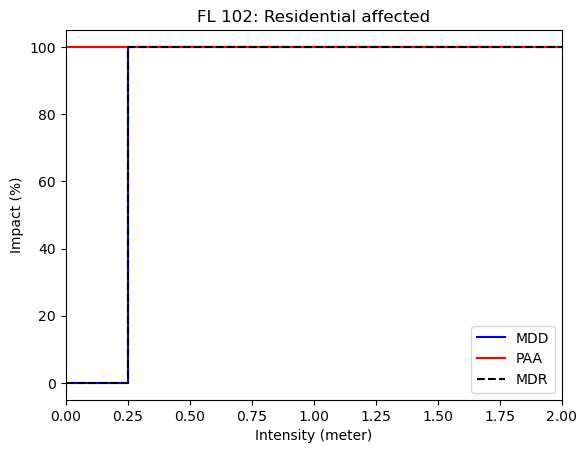

png

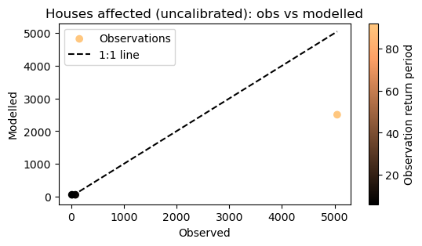

png

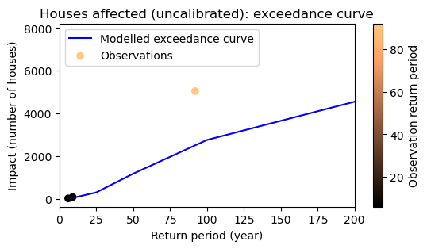

png

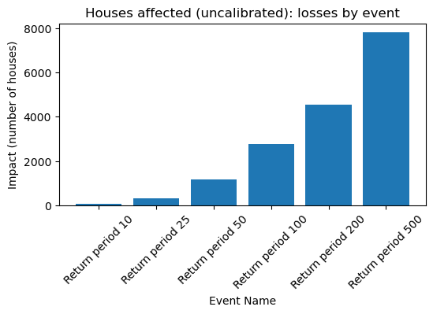

png

#### 7.4.1.1 Discussion: first-guess housing affected analysis

The intial plots show us a few things that can guide the calibration: - We’re improving on a first-guess step function where a house is affected if it has 0.25 m of water or more - This significantly underestimates the impacts from the largest event that we have

This means that we want to reduce the threshold of the step function to increase the number of affected houses.

### 7.4.2 Affected housing: parameter search

The next blocks of code define a simple parameter search to choose this value.

```python
import logging

# This will be a simple grid search, where we loop through all combinations of parameters in a defined parameter space, run the risk calculation for each combination, and calculate the cost function for each combination.
# We then identify the parameter combination that gives the lowest cost function value.

# First: define the parameter space that we'll be exploring
# For a step function this is a single parameter:
parameter_space = {
    "step": np.arange(0.0, 0.55, 0.05)
}

# Define a method to create a step impact function
def step_function(step, fun_id=None, name=None):
    return ImpactFunc.from_step_impf(
        intensity=(0, step, 3),   # The intensity values at which the impact function changes.
        mdd=(0, 1),                # The mean damage degree values below and above the step.
        paa=(1, 1),                # The percentage of assets affected below and above the step.
        haz_type='FL',
        impf_id=fun_id,
        intensity_unit="meter",
        name=name
    )


# Then, we loop through the parameter space, run the risk calculation, and calculate the cost function for each value.
# We store the results in a list.
def search_for_step_impf(
        entity: Entity,
        impf_id: int,
        step_values: np.ndarray,
        obs: pd.Series):
    # Suppress logging from a couple of climada modules which can be very verbose when running many calculations in a loop
    logging.getLogger("climada.engine.impact_calc").setLevel(logging.WARNING)
    logging.getLogger("climada.entity.exposures.base").setLevel(logging.WARNING)

    results = []
    for step in step_values:
        print(f"Running risk calculation for step={step:.2f} ...")

        # Create a new impact function based on the original
        impf_old = entity.impact_funcs.get_func(haz_type='FL', fun_id=impf_id)
        impf_new = step_function(step, fun_id=impf_id, name=impf_old.name)

        # Update the entity object with the new impact function
        entity_new = replace_impact_function(entity, impf_new)

        # Rerun the risk calculation and calculate the cost function as before
        _, modelled_stats = risk_calc(entity_new, haz, return_periods=obs.index)
        cost = cost_function(modelled_stats, obs)

        # Store the results
        results.append({
            "step": step,
            "cost": cost
        })

    logging.getLogger("climada.engine.impact_calc").setLevel(logging.INFO)
    logging.getLogger("climada.entity.exposures.base").setLevel(logging.INFO)
    return pd.DataFrame(results)


results_affected_df = search_for_step_impf(
    entity=entity_affected,
    impf_id=impf_id_affected,
    step_values=parameter_space["step"],
    obs=obs["affected_or_destroyed_present"]
)
display(results_affected_df)
```

```
Running risk calculation for step=0.00 ...
2026-07-02 13:28:47,747 - climada.hazard.base - WARNING - Impact function id=102 has mdr(0) != 0.The mean damage ratio must thus be computed for all values ofhazard intensity including 0 which can be very time consuming.
Running risk calculation for step=0.05 ...
Running risk calculation for step=0.10 ...
Running risk calculation for step=0.15 ...
Running risk calculation for step=0.20 ...
Running risk calculation for step=0.25 ...
Running risk calculation for step=0.30 ...
Running risk calculation for step=0.35 ...
Running risk calculation for step=0.40 ...
Running risk calculation for step=0.45 ...
Running risk calculation for step=0.50 ...
```

|  | step | cost |
| --- | --- | --- |
| 0 | 0.00 | 1043.986796 |
| 1 | 0.05 | 1136.811477 |
| 2 | 0.10 | 1226.440995 |
| 3 | 0.15 | 1311.581459 |
| 4 | 0.20 | 1395.381213 |
| 5 | 0.25 | 1468.574032 |
| 6 | 0.30 | 1539.226029 |
| 7 | 0.35 | 1608.680337 |
| 8 | 0.40 | 1673.619199 |
| 9 | 0.45 | 1747.718456 |
| 10 | 0.50 | 1811.162402 |

From this search we can identify the ‘best’ impact function and visualize the results:

```python
# Get the index of the minimum value of 'cost'
def get_best_result(results_df):
    ix_best = results_df['cost'].idxmin()
    best_parameters = results_df.loc[ix_best, :]
    return dict(best_parameters)

best_affected_parameters = get_best_result(results_affected_df)
print(f"Best step value: {best_affected_parameters['step']:.2f} with cost: {best_affected_parameters['cost']:.2f}")
```

```
Best step value: 0.00 with cost: 1043.99
```

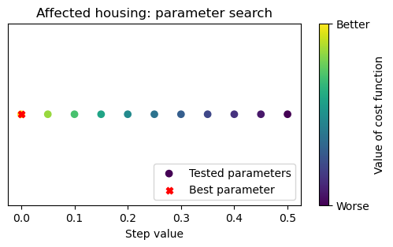

png

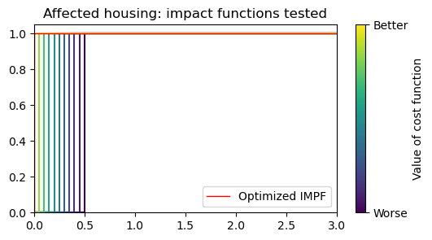

png

```python
from matplotlib.colors import to_hex

# -------------------------------------------
# Methods to visualize the parameter search
# -------------------------------------------

# Helper function for assigning colours to scatter points
def assign_colour_to_costs(results_df):
    # Map the cost to a color according to viridis, where the best score (lowest) is yellow and the worst score (highest) is purple
    # we can do this by normalising the cost to be between 0 and 1, where 0 corresponds to the best 1 corresponds to the worst score
    # In addition, we take the logarithm of the cost to make the differences between smaller costs more visible
    costs = np.log10(results_df['cost'] + 1e-6)  # Add a small value to avoid taking log of zero
    max_score = costs.max()
    min_score = costs.min()
    norm_scores = 1 - (costs - min_score) / (max_score - min_score)
    results_df['colour'] = [to_hex(plt.cm.viridis(score)) for score in norm_scores]
    results_df = results_df.sort_values('cost', ascending=False)  # Also sort the dataframe by cost so that the best scores are plotted on top
    return results_df

# Plot the parameter search space, with points coloured according to the cost function value (yellow = good, purple = bad)
def plot_step_search_space(results_df, best_step, title):
    results_df = assign_colour_to_costs(results_df)
    fig, axis = plt.subplots(figsize=(6, 3))
    axis.scatter(results_df['step'], np.zeros_like(results_df['step']), color=results_df['colour'], label='Tested parameters')
    axis.scatter(best_step, 0, color='red', label='Best parameter', marker='X')
    axis.legend(loc="lower right")

    axis.cbar = plt.colorbar(plt.cm.ScalarMappable(cmap='viridis'), ax=axis)
    axis.cbar.set_label('Value of cost function')
    axis.cbar.set_ticks([0, 1])
    axis.cbar.set_ticklabels(['Worse', 'Better'])

    axis.set_xlabel("Step value")
    axis.set_yticks([])
    axis.set_title(title)
    plt.show()
    plt.close(axis.figure)

# Plot all the impact functions tested in the parameter search, coloured according to the cost function value
def plot_step_search_impfs(results_df, best_step, title):
    results_df = assign_colour_to_costs(results_df)
    fig, axis = plt.subplots(figsize=(6, 3))
    for _, params in results_df.iterrows():
        impf_new = step_function(params['step'])
        axis.plot(impf_new.intensity, impf_new.mdd, color=params['colour'])

    best_impf = step_function(best_step)
    axis.plot(best_impf.intensity, best_impf.mdd, color='red', linewidth=1, label='Optimized IMPF')
    axis.legend(loc="lower right")

    axis.set_xlim((best_impf.intensity.min(), best_impf.intensity.max()))
    axis.set_ylim((0, 1.05))

    axis.cbar = plt.colorbar(plt.cm.ScalarMappable(cmap='viridis'), ax=axis)
    axis.cbar.set_label('Value of cost function')
    axis.cbar.set_ticks([0, 1])
    axis.cbar.set_ticklabels(['Worse', 'Better'])

    axis.set_title(title)
    plt.show()
    plt.close(axis.figure)

plot_step_search_space(results_affected_df, best_affected_parameters['step'], "Affected housing: parameter search")
plot_step_search_impfs(results_affected_df, best_affected_parameters['step'], "Affected housing: impact functions tested")
```

### 7.4.3 Affected housing: the optimized impact function

(Note that we don’t call this ‘calibrated’ – an automated search won’t always choose the best function!)

```python
# Recreate the impact calculation with the best parameter values:
impf_best_affected = step_function(best_affected_parameters['step'], fun_id=default_impf_affected.id, name=default_impf_affected.name)

# Update the entity object with the new impact function
entity_affected = replace_impact_function(entity_count, impf_best_affected)

# Rerun the risk calculation and calculate the cost function as before
imp, modelled_stats = risk_calc(entity_affected, haz, return_periods=obs.index)
cost = cost_function(modelled_stats, obs['affected_or_destroyed_present'])

title = f"Houses affected (optimized): obs vs modelled"
plot_observations_vs_modelled(obs["affected_or_destroyed_present"], modelled_stats, title)
title = f"Houses affected (optimized): exceedance curve"
plot_exceedance(imp, obs["affected_or_destroyed_present"], title)
title = f"Houses affected (optimized): losses by event"
plot_event_losses(imp, title=title)
```

```
2026-07-02 13:28:49,759 - climada.entity.exposures.base - INFO - Exposures matching centroids already found for FL
2026-07-02 13:28:49,782 - climada.engine.impact_calc - INFO - Calculating impact for 29925 assets (>0) and 6 events.
2026-07-02 13:28:49,788 - climada.hazard.base - WARNING - Impact function id=102 has mdr(0) != 0.The mean damage ratio must thus be computed for all values ofhazard intensity including 0 which can be very time consuming.
```

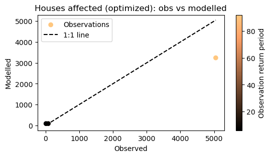

png

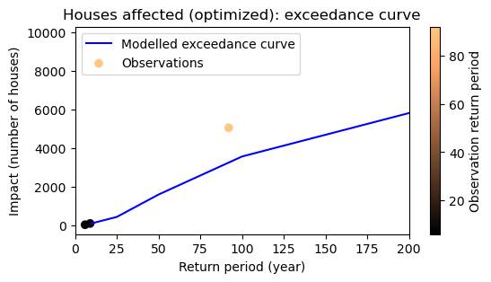

png

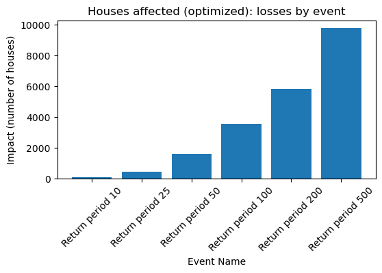

png

#### 7.4.3.1 Discussion: optimized housing affected

The selected impact function for affected houses is a dramatic one: any hazard at all is considered to have affected a house.

From the plots above we see that this still underestimates the official figures for damaged housing. There could be several reasons for this: - The damage reports overestimate losses - The historic event had a larger flood footprint than the return periods we’ve matched it to (though we chose quite a large return period after seeing how poorly the calibration performed at lower return periods) - Our exposure data doesn’t have enough houses, or they are not located close enough to flooded locations

Each of these would require some more careful validation. For now this is sufficient: in our model we consider any house that experienced flooding to have been affected.

## 7.5 Destroyed housing calibration: step function

For destroyed housing we also use a step function. The calibration repeats the above calculations, and we expect to find a higher intensity threshold.

### 7.5.1 First-guess analysis

First, look at the first-guess results:

```python
# Modify our Entity to use the default 'destroyed' impact function
default_impf_destroyed = entity_count.impact_funcs.get_func(haz_type='FL', fun_id=impf_id_destroyed)
entity_destroyed = replace_impact_function(entity_count, default_impf_destroyed)

# Calculate risk
imp_destroyed, modelled_destroyed = risk_calc(entity_destroyed, haz, return_periods=obs.index)
cost = cost_function(modelled_destroyed, obs["homes_destroyed_present"])

# Create plots
entity_destroyed.impact_funcs.plot()
title = f"Houses destroyed (uncalibrated): obs vs modelled"
plot_observations_vs_modelled(obs["homes_destroyed_present"], modelled_destroyed, title)
title = f"Houses destroyed (uncalibrated): exceedance curve"
plot_exceedance(imp_destroyed, obs["homes_destroyed_present"], title)
title = f"Houses destroyed (uncalibrated): losses by event"
plot_event_losses(imp_destroyed, title=title)
```

```
2026-07-02 13:28:50,340 - climada.entity.exposures.base - INFO - Exposures matching centroids already found for FL
2026-07-02 13:28:50,369 - climada.engine.impact_calc - INFO - Calculating impact for 29925 assets (>0) and 6 events.
```

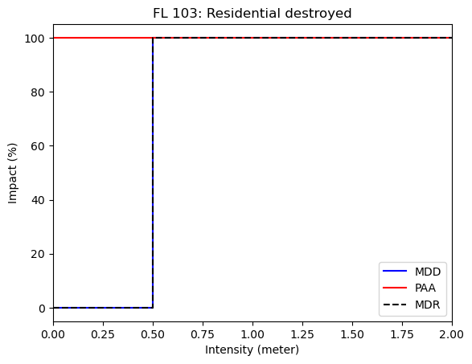

png

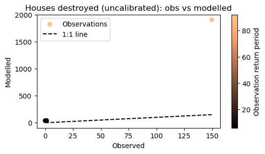

png

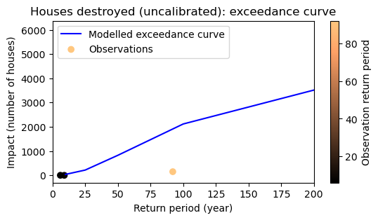

png

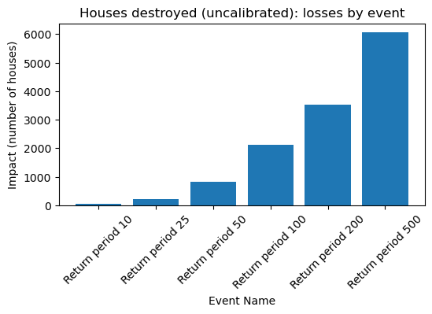

png

#### 7.5.1.1 Discussion: first-guess housing destroyed

The intial plots show us a few things that can guide the calibration.: - We’re improving on a first-guess step function where a house is affected if it has 0.5 m of water or more - This mayjorly *overestimates* the impacts from the largest event that we have

This means that we want to increase the threshold of the step function to decrease the number of destroyed houses.

### 7.5.2 Destroyed housing: parameter search

The next blocks of code define a simple parameter search to choose this value.

```python
parameter_space = {
    "step": np.arange(0.5, 3.05, 0.05)
}

results_destroyed_df = search_for_step_impf(
    entity=entity_destroyed,
    impf_id=impf_id_destroyed,
    step_values=parameter_space["step"],
    obs=obs["homes_destroyed_present"]
)
display(results_destroyed_df)
```

[output not shown]

|  | step | cost |
| --- | --- | --- |
| 0 | 0.50 | 1017.069979 |
| 1 | 0.55 | 945.528993 |
| 2 | 0.60 | 890.250136 |
| 3 | 0.65 | 832.272268 |
| 4 | 0.70 | 763.445528 |
| 5 | 0.75 | 709.509564 |
| 6 | 0.80 | 650.338785 |
| 7 | 0.85 | 602.457957 |
| 8 | 0.90 | 560.452359 |
| 9 | 0.95 | 514.166336 |
| 10 | 1.00 | 474.539974 |
| 11 | 1.05 | 444.751273 |
| 12 | 1.10 | 405.197373 |
| 13 | 1.15 | 365.798541 |
| 14 | 1.20 | 326.469499 |
| 15 | 1.25 | 292.174957 |
| 16 | 1.30 | 270.512824 |
| 17 | 1.35 | 247.326499 |
| 18 | 1.40 | 221.068695 |
| 19 | 1.45 | 192.940307 |
| 20 | 1.50 | 167.052593 |
| 21 | 1.55 | 142.411559 |
| 22 | 1.60 | 115.692221 |
| 23 | 1.65 | 98.325932 |
| 24 | 1.70 | 79.504955 |
| 25 | 1.75 | 57.959490 |
| 26 | 1.80 | 40.179137 |
| 27 | 1.85 | 30.689551 |
| 28 | 1.90 | 4.961968 |
| 29 | 1.95 | 4.072340 |
| 30 | 2.00 | 14.486343 |
| 31 | 2.05 | 25.009459 |
| 32 | 2.10 | 33.320642 |
| 33 | 2.15 | 39.116053 |
| 34 | 2.20 | 47.359429 |
| 35 | 2.25 | 56.573022 |
| 36 | 2.30 | 59.667375 |
| 37 | 2.35 | 63.246694 |
| 38 | 2.40 | 66.156354 |
| 39 | 2.45 | 66.710577 |
| 40 | 2.50 | 69.620255 |
| 41 | 2.55 | 69.804997 |
| 42 | 2.60 | 71.837162 |
| 43 | 2.65 | 72.807061 |
| 44 | 2.70 | 74.146447 |
| 45 | 2.75 | 75.116349 |
| 46 | 2.80 | 77.310180 |
| 47 | 2.85 | 77.679667 |
| 48 | 2.90 | 79.619481 |
| 49 | 2.95 | 82.529208 |
| 50 | 3.00 | 86.408857 |

```python
best_destroyed_parameters = get_best_result(results_destroyed_df)
print(f"Best step value: {best_destroyed_parameters['step']:.2f} with cost: {best_destroyed_parameters['cost']:.2f}")

plot_step_search_space(results_destroyed_df, best_destroyed_parameters['step'], title="Destroyed housing: parameter search")
plot_step_search_impfs(results_destroyed_df, best_destroyed_parameters['step'], title="Destroyed housing: impact functions tested")
```

```
Best step value: 1.95 with cost: 4.07
```

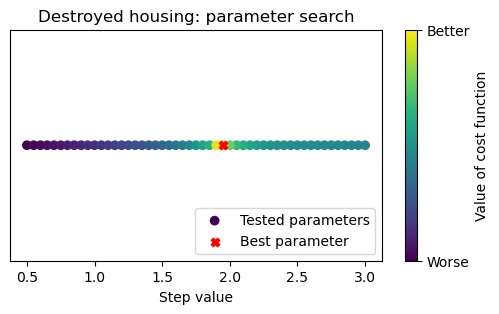

png

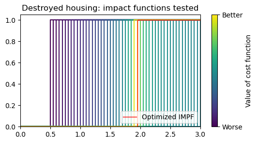

png

```python
# Recreate the impact calculation with the best parameter values:
impf_best_destroyed = step_function(best_destroyed_parameters['step'], fun_id=default_impf_destroyed.id, name=default_impf_destroyed.name)

# Update the entity object with the new impact function
entity_destroyed = replace_impact_function(entity_count, impf_best_destroyed)

# Rerun the risk calculation and calculate the cost function as before
imp, modelled_stats = risk_calc(entity_destroyed, haz, return_periods=obs.index)
cost = cost_function(modelled_stats, obs['homes_destroyed_present'])

title = f"Houses destroyed (optimized): obs vs modelled"
plot_observations_vs_modelled(obs["homes_destroyed_present"], modelled_stats, title=title)
title = f"Houses destroyed (optimized): exceedance curve"
plot_exceedance(imp, obs["homes_destroyed_present"], title=title)
title = f"Houses destroyed (optimized): losses by event"
plot_event_losses(imp, title=title)
```

```
2026-07-02 13:28:57,289 - climada.entity.exposures.base - INFO - Exposures matching centroids already found for FL
2026-07-02 13:28:57,306 - climada.engine.impact_calc - INFO - Calculating impact for 29925 assets (>0) and 6 events.
```

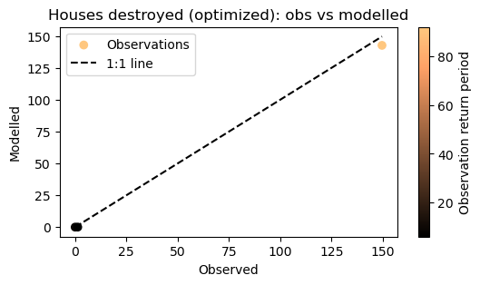

png

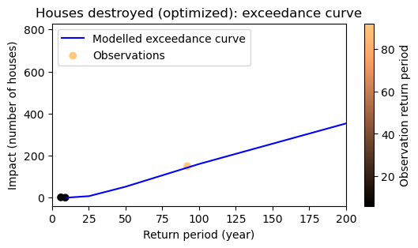

png

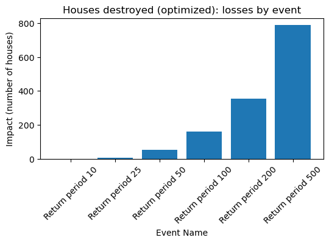

png

#### 7.5.2.1 Discussion: optimized housing destroyed

The selected impact function - a damage threshold at just below 2m of water depth – feels like a reasonable one for the destruction of a house.

The model is able to reproduce the historical observations with quite some accuracy. It gets realistic low return period impacts (houses are not destroyed every year) and gets the main historic observation right.

Not included here is the uncertainty: the fitted function is sensitive to the return period that we assign to the 2017 flood events – change the value of `RETURN_PERIOD_2017` in these scripts to confirm this.

## 7.6 Recovery costs: loss curve calibration

Now we look at calibrating a loss curve for economic costs. The goal here is to reproduce the reported government expenditure on recovery and reconstruction of housing.

Note that this is different to the modelling the value of the houses (and contents) lost – the reported expenditure per house is far below the value of a house in our Entity file.

This calibration is more complex: we want to adjust an existing flood loss curve rather than create one from its functional form. There are a lot of ways to do this: here we will apply scalings along the x- and y-axis to stretch the first-guess function (capping a cap at 100% loss). Other approaches might translate along the x-axis instead of stretching, or might look at ways to change the shape of the function.

### 7.6.1 First-guess analysis

Our Entity file has a first-guess impact function for housing losses. This is what we’ll be improving on:

First, look at the first-guess results:

```python
# Calculate uncalibrated losses
imp_losses, modelled_losses = risk_calc(entity_usd, haz, return_periods=obs.index)  # No need to change the impact function since the Entity file is set up to use the loss curve by deafult
cost = cost_function(modelled_losses, obs["recovery_cost_usd"])
default_impf_loss = entity_usd.impact_funcs.get_func(haz_type='FL', fun_id=impf_id_loss)

default_impf_loss.plot()
title = f"Recovery costs (uncalibrated): obs vs modelled"
plot_observations_vs_modelled(obs["recovery_cost_usd"], modelled_losses, title)
title = f"Recovery costs (uncalibrated): exceedance curve"
plot_exceedance(imp_losses, obs["recovery_cost_usd"], title=title)
title = f"Recovery costs (uncalibrated): losses by event"
plot_event_losses(imp_losses, title=title)
```

```
2026-07-02 13:28:57,832 - climada.entity.exposures.base - INFO - Exposures matching centroids already found for FL
2026-07-02 13:28:57,852 - climada.engine.impact_calc - INFO - Calculating impact for 29925 assets (>0) and 6 events.
```

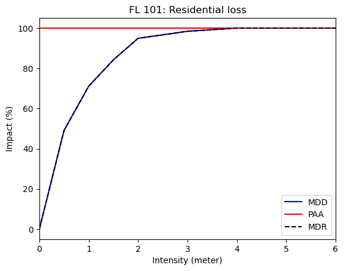

png

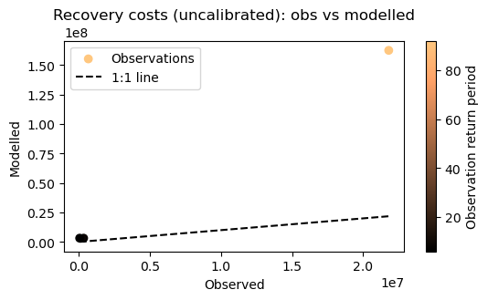

png

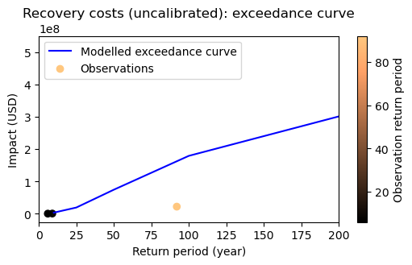

png

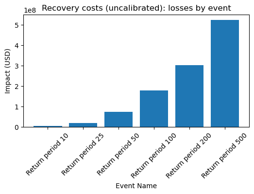

png

#### 7.6.1.1 Discussion: first-guess recovery costs analysis

The intial plots show us a few things that can guide the calibration: - We’re improving on a moderately steep first-guess curve. Losses start quickly (as opposed to, for example, a sigmoid curve), and by 2 m flood depth there is almost 100% loss. - This agrees with what we found in our ‘destroyed’ modelling earlier. - *However* we know that the ‘recovery cost’ for a house is far lower than the Entity file’s housing value  
- Therefore we see that the first-guess impact function creates losses that are much much higher than the recovery costs.

This means that we want a weaker impact function. We would perhaps imagine a strong scaling on the y-axis so that the maximum possible loss is lower, and small adjustments from x-axis scaling; it makes sense for the function to max out at about 2 m.

### 7.6.2 Recovery costs: parameter search

The next blocks of code define the parameter search:

```python
import logging

# This will be a simple grid search, where we loop through all combinations of parameters in a defined parameter space, run the risk calculation for each combination, and calculate the cost function for each combination.
# We then identify the parameter combination that gives the lowest cost function value.

# First: define the parameter space that we'll be exploring
# We now use two parameters:
parameter_space = {
    "x_scale": np.arange(0.2, 2.6, 0.04),    # Scaling along the x-axis
    "y_scale": np.arange(0.1, 0.4025, 0.02)    # Scaling along the y-axis
}

# Define a method that scales an impact function
def scale_impf(impf, x_scale, y_scale):
    impf_new = copy.deepcopy(impf)   # Make a copy of the impact function to adjust
    impf_new.intensity = impf_new.intensity * x_scale
    impf_new.mdd = impf_new.mdd * y_scale
    impf_new.mdd = np.clip(impf_new.mdd, 0, 1)   # Ensure that the damage fraction stays between 0 and 1
    return impf_new


def search_for_loss_impf(
        entity: Entity,
        impf_id: int,
        param_space: dict,
        obs: pd.Series
    ):
    # Suppress logging from a couple of climada modules which can be very verbose when running many calculations in a loop
    logging.getLogger("climada.engine.impact_calc").setLevel(logging.WARNING)
    logging.getLogger("climada.entity.exposures.base").setLevel(logging.WARNING)

    results = []
    for x_scale in param_space["x_scale"]:
        print(f"Running risk calculations for x_scale={x_scale:.3f} with {len(param_space['y_scale'])} y_scale values...")
        for y_scale in param_space["y_scale"]:
            # Create a new impact function based on the original
            impf_loss = entity.impact_funcs.get_func(haz_type='FL', fun_id=impf_id)
            impf_new = scale_impf(impf_loss, x_scale, y_scale)

            # Update the entity object with the new impact function
            entity_new = replace_impact_function(entity, impf_new)

            # Rerun the risk calculation and calculate the cost function as before
            _, modelled_stats = risk_calc(entity_new, haz, return_periods=obs.index)
            cost = cost_function(modelled_stats, obs)

            # Store the results
            results.append({
                "x_scale": x_scale,
                "y_scale": y_scale,
                "cost": cost
            })

    logging.getLogger("climada.engine.impact_calc").setLevel(logging.INFO)
    logging.getLogger("climada.entity.exposures.base").setLevel(logging.INFO)

    return pd.DataFrame(results)

results_loss_df = search_for_loss_impf(
    entity=entity_usd,
    impf_id=impf_id_loss,
    param_space=parameter_space,
    obs=obs["recovery_cost_usd"]
)
display(results_loss_df.sort_values('cost').head(10))
```

[output not shown]

|  | x_scale | y_scale | cost |
| --- | --- | --- | --- |
| 887 | 2.40 | 0.24 | 179409.618996 |
| 790 | 2.16 | 0.22 | 182574.422563 |
| 677 | 1.88 | 0.20 | 191636.062239 |
| 467 | 1.36 | 0.16 | 199379.880253 |
| 580 | 1.64 | 0.18 | 205493.383187 |
| 354 | 1.08 | 0.14 | 208023.921005 |
| 903 | 2.44 | 0.24 | 212653.769371 |
| 241 | 0.80 | 0.12 | 219206.859090 |
| 774 | 2.12 | 0.22 | 229586.589428 |
| 693 | 1.92 | 0.20 | 230010.414795 |

```python
# ------------------------------------
# Visualize the parameter search results, now in two dimensions
# ------------------------------------

def plot_loss_search_space(results_df, best_params):
    # Map the cost to a color according to viridis, where the best score (lowest) is yellow and the worst score (highest) is purple
    # we can do this by normalising the cost to be between 0 and 1, where 0 corresponds to the best 1 corresponds to the worst score
    results_df = assign_colour_to_costs(results_df)
    fig, axis = plt.subplots(figsize=(6, 3))
    axis.scatter(results_df['x_scale'], results_df['y_scale'], color=results_df['colour'])
    axis.scatter(best_params['x_scale'], best_params['y_scale'], color='red', label='Best parameter combination', marker='X')
    axis.set_xlabel("X scaling")
    axis.set_ylabel("Y scaling")
    axis.set_title("Parameter search results")

def plot_loss_search_impfs(results_df, best_params, impf_orig):
    results_df = assign_colour_to_costs(results_df)
    fig, axis = plt.subplots(figsize=(6, 3))
    for _, params in results_df.iterrows():
        impf_new = scale_impf(impf_orig, params['x_scale'], params['y_scale'])
        axis.plot(impf_new.intensity, impf_new.mdd, color=params['colour'])

    best_impf = scale_impf(impf_orig, best_params['x_scale'], best_params['y_scale'])
    axis.plot(best_impf.intensity, best_impf.mdd, color='red', linewidth=1, label='Optimized IMPF')

    axis.set_xlim((best_impf.intensity.min(), best_impf.intensity.max()))
    axis.set_ylim((0, 1.05))
    axis.set_title("Impact functions tested")

    plt.show()
    plt.close(axis.figure)

best_loss_parameters = get_best_result(results_loss_df)
print(f"Best parameter combination: x_scale: {best_loss_parameters['x_scale']:.2f}, y_scale: {best_loss_parameters['y_scale']:.2f} with cost: {best_loss_parameters['cost']:.2f}")

impf_orig = entity_usd.impact_funcs.get_func(haz_type='FL', fun_id=impf_id_loss)
plot_loss_search_space(results_loss_df, best_loss_parameters)
plot_loss_search_impfs(results_loss_df, best_loss_parameters, impf_orig)
```

```
Best parameter combination: x_scale: 2.40, y_scale: 0.24 with cost: 179409.62
```

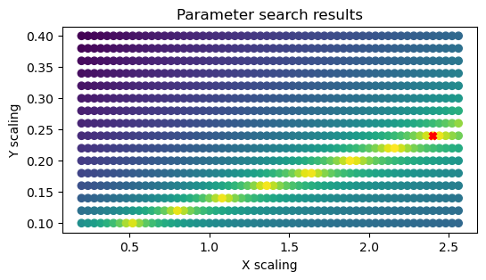

png

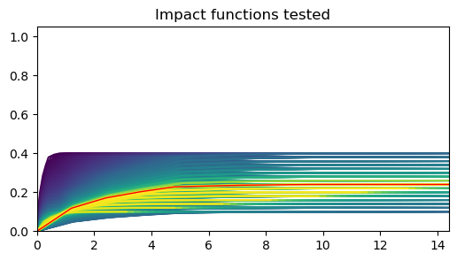

png

```python
# Recreate the impact calculation with the best parameter values:
impf_best_loss = scale_impf(impf_orig, best_loss_parameters['x_scale'], best_loss_parameters['y_scale'])

# Update the entity object with the new impact function
entity_loss = replace_impact_function(entity_usd, impf_best_loss)

# Rerun the risk calculation and calculate the cost function as before
imp_optimized, modelled_stats = risk_calc(entity_loss, haz, return_periods=obs.index)
cost = cost_function(modelled_stats, obs['recovery_cost_usd'])

title = f"Recovery costs (optimized): obs vs modelled"
plot_observations_vs_modelled(obs["recovery_cost_usd"], modelled_stats, title=title)
title = f"Recovery costs (optimized): exceedance curve"
plot_exceedance(imp, obs["recovery_cost_usd"], title=title)
title = f"Recovery costs (optimized): losses by event"
plot_event_losses(imp, title=title)
title = f"Recovery costs (optimized): map of expected annual impacts"
plot_map(imp, title=title)
```

```
2026-07-02 13:31:23,759 - climada.entity.exposures.base - INFO - Exposures matching centroids already found for FL
2026-07-02 13:31:23,800 - climada.engine.impact_calc - INFO - Calculating impact for 29925 assets (>0) and 6 events.
```

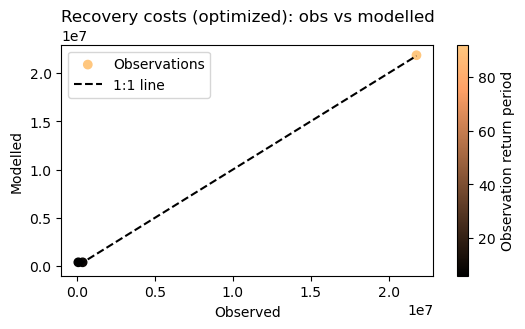

png

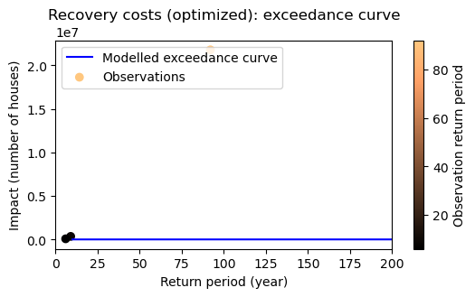

png

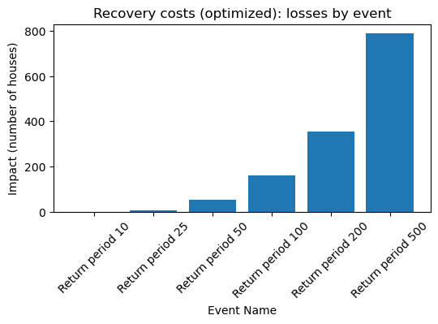

png

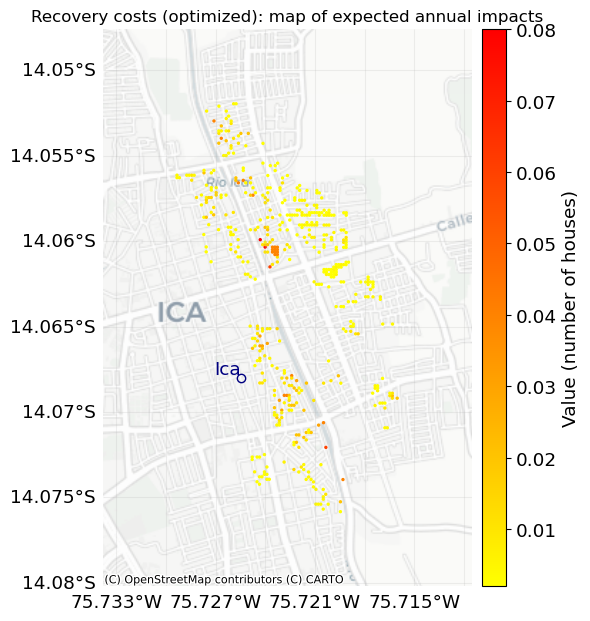

png

#### 7.6.2.1 Discussion: optimized recover costs analysis

The model is able to reproduce the historical observations with quite some accuracy. It gets realistic low return period impacts (houses are not destroyed every year) and gets the main historic observations right.

How would we improve this function? Looking at the above plot of the cost function in the two-dimensional parameter space, we can see that there is a linear band of similarly-good choices in yellow stretching from lower left to upper right, including a region with lower x_scale and y_scale values, i.e. relatively steeper curves that cap out sooner. The cost function is similar across the entire band.

I would therefore suggest taking one of these functions: a slightly less efficient match in the cost function is worth a better agreement with the theory.

For example, how do results change with `x_scale = 0.8` `y_scale = 0.12`?

```python
# Create a new impact function based on the original
alt_x_scale = 0.8
alt_y_scale = 0.12
impf_loss_default = entity_usd.impact_funcs.get_func(haz_type='FL', fun_id=impf_id_loss)
impf_alt_loss = scale_impf(impf_loss_default, alt_x_scale, alt_y_scale)

# Update the entity object with the new impact function
entity_alt = replace_impact_function(entity_usd, impf_alt_loss)

# Rerun the risk calculation and calculate the cost function as before
imp_alt, modelled_stats = risk_calc(entity_alt, haz, return_periods=obs.index)
cost = cost_function(modelled_stats, obs["recovery_cost_usd"])

# Store the results
results_alt = {
    "x_scale": alt_x_scale,
    "y_scale": alt_y_scale,
    "cost": cost
}

print(f"Optimized cost function: {best_loss_parameters['cost']:.0f}")
print(f"Alternative cost function: {results_alt['cost']:.0f}")

# Plot the two impact functions
fig, axis = plt.subplots(figsize=(6, 4))
axis.plot(impf_best_loss.intensity, impf_best_loss.mdd, color='blue', label='Optimized')
axis.plot(impf_alt_loss.intensity, impf_alt_loss.mdd, color='green', label='Alternative')
axis.set_xlabel("Hazard intensity (m)")
axis.set_ylabel("Impact (%)")
axis.set_xlim((0, 4))
axis.legend(loc="upper left")
axis.set_title("Comparison of impact functions")

# Compare the two Exceedance curves
fig, axis = plt.subplots(figsize=(6, 4))
# Plot the optimized curve
exceedance_curve_opt = imp_optimized.calc_freq_curve()
exceedance_curve_alt = imp_alt.calc_freq_curve()
exceedance_curve_opt.plot(axis=axis, color="blue", label="Optimized")
exceedance_curve_alt.plot(axis=axis, color="green", label="Alternative")
axis.scatter(obs.index, obs["recovery_cost_usd"], c=obs.index, cmap="copper", label="Observations")
# axis.set_xlim(0, 500)  # Don't zoom in on lower return periods
axis.set_title("Impact function comparison: exceedance curves")
axis.set_xlabel("Return period (years)")
axis.set_ylabel("Recovery cost (USD)")
axis.legend(loc="lower right")
plt.show()
plt.close(axis.figure)
```

```
2026-07-02 13:31:28,439 - climada.entity.exposures.base - INFO - Exposures matching centroids already found for FL
2026-07-02 13:31:28,466 - climada.engine.impact_calc - INFO - Calculating impact for 29925 assets (>0) and 6 events.
Optimized cost function: 179410
Alternative cost function: 219207
```

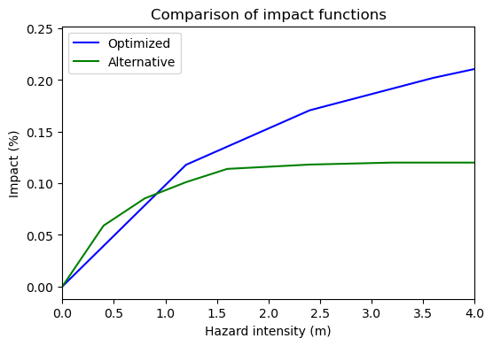

png

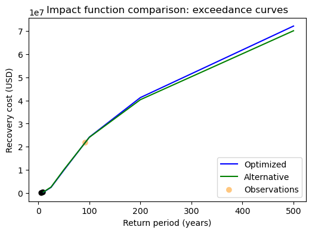

png

We see that, while these are quite different functions, they create remarkably similar exceedance curves. We can conclude that the results are not very sensitive to this choice, and so it’s reasonable to pick the one that makes more ‘intuitive’ sense here.

## 7.7 Write calibrated Entity file

```python
import shutil

entity_final = copy.deepcopy(entity_usd)

# Swap in the new impact functions for loss, affected, and destroyed
new_impfset = ImpactFuncSet([impf_alt_loss, impf_best_affected, impf_best_destroyed])
old_impf_ids = [impf.id for impf in entity_final.impact_funcs.get_func(haz_type='FL')]
new_impf_ids = [impf.id for impf in new_impfset.get_func(haz_type='FL')]
assert np.array_equal(old_impf_ids, new_impf_ids), "The new impact function IDs do not match the old ones"
entity_final.impact_funcs = new_impfset

# Drop unnecessary columns that were added to the Exposures GeoDataFrame
new_gdf = entity_final.exposures.gdf.copy()
columns_to_drop = [col for col in new_gdf.columns if col.startswith("centr_")]
new_gdf = new_gdf.drop(columns=columns_to_drop)
entity_final.exposures.set_gdf(new_gdf)

# Copy over original file and update with calibrated impact functions
shutil.copy(entity_filepath, calibrated_entity_filepath)

# Open the impact_functions sheet in the Excel file and overwrite with the new impact functions
impf_export_list = []
for impf in [impf_alt_loss, impf_best_affected, impf_best_destroyed]:
    impf_df = pd.DataFrame({
        "impact_fun_id": impf.id,
        "intensity_m": impf.intensity,
        "mdd": impf.mdd,
        "paa": impf.paa,
        "peril_id": "FL",
        "name": impf.name,
        "intensity_unit": "meter"
    })
    impf_export_list.append(impf_df)

impf_export_df = pd.concat(impf_export_list, ignore_index=True)

print(f"Final impact functions. Copy into Excel file to overwrite the original impact functions:")
display(impf_export_df.style.format({
    "impact_fun_id": "{:d}",
    "intensity_m": "{:.3f}",
    "mdd": "{:.3f}",
    "paa": "{:.3f}"
}))
```

```
Final impact functions. Copy into Excel file to overwrite the original impact functions:
```

|  | impact_fun_id | intensity_m | mdd | paa | peril_id | name | intensity_unit |
| --- | --- | --- | --- | --- | --- | --- | --- |
| 0 | 101 | 0.000 | 0.000 | 1.000 | FL | Residential loss | meter |
| 1 | 101 | 0.400 | 0.059 | 1.000 | FL | Residential loss | meter |
| 2 | 101 | 0.800 | 0.085 | 1.000 | FL | Residential loss | meter |
| 3 | 101 | 1.200 | 0.101 | 1.000 | FL | Residential loss | meter |
| 4 | 101 | 1.600 | 0.114 | 1.000 | FL | Residential loss | meter |
| 5 | 101 | 2.400 | 0.118 | 1.000 | FL | Residential loss | meter |
| 6 | 101 | 3.200 | 0.120 | 1.000 | FL | Residential loss | meter |
| 7 | 101 | 4.000 | 0.120 | 1.000 | FL | Residential loss | meter |
| 8 | 101 | 4.800 | 0.120 | 1.000 | FL | Residential loss | meter |
| 9 | 102 | 0.000 | 0.000 | 1.000 | FL | Residential affected | meter |
| 10 | 102 | 0.000 | 0.000 | 1.000 | FL | Residential affected | meter |
| 11 | 102 | 0.000 | 1.000 | 1.000 | FL | Residential affected | meter |
| 12 | 102 | 3.000 | 1.000 | 1.000 | FL | Residential affected | meter |
| 13 | 103 | 0.000 | 0.000 | 1.000 | FL | Residential destroyed | meter |
| 14 | 103 | 1.950 | 0.000 | 1.000 | FL | Residential destroyed | meter |
| 15 | 103 | 1.950 | 1.000 | 1.000 | FL | Residential destroyed | meter |
| 16 | 103 | 3.000 | 1.000 | 1.000 | FL | Residential destroyed | meter |

# 8 Future Risk

Here we run a calculation for future risk, looking at how growth and climate change affect future modelled impacts.

In this notebook we will

- Create a future Entity object, where future assets are created from present-day assets, with scaled values according to projected growth.
- Create a future Hazard object, where we adjust the frequencies of present-day events to reflect future changes in climate risk
- Create a waterfall plot breaking down future changes in risk into growth and climate change.

Here we examine the Residential risk.

```python
# -------------------------------
# Specify parameters for the analysis
# -------------------------------

YEAR_PRESENT = 2025
YEAR_FUTURE = 2050
```

```python
from pathlib import Path

# -------------------------------
# Set up paths to data
# -------------------------------

# Entity files
ENTITY_DIR = "../data/entity_files_calibrated/"
ENTITY_FILE = "ICA_PERU_Entity_Floods_Residential_calibrated.xlsx"
entity_filepath = Path(ENTITY_DIR) / ENTITY_FILE

# Hazard .tif layers
HAZARD_DIR = "../data/hazard/"
HAZARD_FILES = ["tr10_h_max_61200_4326.tif", "tr25_h_max_61200_4326.tif", "tr50_h_max_61200_4326.tif", "tr100_h_max_61200_4326.tif", "tr200_h_max_61200_4326.tif", "tr500_h_max_72000_4326.tif"]
haz_filepaths = [Path(HAZARD_DIR) / filename for filename in HAZARD_FILES]

# Socioeconomic growth projections
GROWTH_RATES_FILEPATH = "../data/socioeconomic_change/growth_projections.csv"
# Projected future changes in hazard return periods
RP_MAPPING_FILEPATH = "../data/hazard/ica_rp_mapping_2025_2050.csv"
```

## 8.1 Create present-day and future Entity objects

### 8.1.1 Read in present-day Entity file

```python
import copy
from climada.entity import Entity

# Read the Entity file and set additional metadata for the Exposures
print(f"Reading {entity_filepath}...")
entity_present = Entity.from_excel(entity_filepath)
entity_present.exposures.ref_year = YEAR_PRESENT
entity_present.exposures.value_unit = "USD"
entity_present.exposures.description = f"Residential Exposures (Present, {YEAR_PRESENT})"
```

```
Reading ../data/entity_files_calibrated/ICA_PERU_Entity_Floods_Residential_calibrated.xlsx...
```

### 8.1.2 Apply projected growth to Exposures

There are two ways to create a future Entity object: directly in an Excel file, or by making adjustments in code. In general only the Exposures change between present-day and future Entity objects: everything else (impact functions, discount rates, measures) should remain the same. Otherwise you may get unexpected behavior.

In this analysis, our future assets are created by scaling present-day asset values. Their geographic location remains the same. This is most easily done in code (and saves us from updating two versions of the Entity file when we make changes to other sheets in the file).

```python
import pandas as pd

# Load growth rate data
growth_rates_df = pd.read_csv(GROWTH_RATES_FILEPATH).set_index("Year")

# Filter to years between present and future
growth_rates_df = growth_rates_df.loc[(growth_rates_df.index > YEAR_PRESENT) & (growth_rates_df.index <= YEAR_FUTURE)]
display(growth_rates_df)
```

| Year | Population Growth Estimates | GDP Growth Rate |
| --- | --- | --- |
| 2026 | 0.010 | 0.025 |
| 2027 | 0.009 | 0.028 |
| 2028 | 0.009 | 0.027 |
| 2029 | 0.009 | 0.027 |
| 2030 | 0.008 | 0.028 |
| 2031 | 0.008 | 0.030 |
| 2032 | 0.008 | 0.033 |
| 2033 | 0.007 | 0.035 |
| 2034 | 0.007 | 0.035 |
| 2035 | 0.007 | 0.035 |
| 2036 | 0.007 | 0.034 |
| 2037 | 0.006 | 0.034 |
| 2038 | 0.006 | 0.032 |
| 2039 | 0.006 | 0.032 |
| 2040 | 0.006 | 0.030 |
| 2041 | 0.005 | 0.030 |
| 2042 | 0.005 | 0.028 |
| 2043 | 0.005 | 0.023 |
| 2044 | 0.005 | 0.022 |
| 2045 | 0.005 | 0.022 |
| 2046 | 0.004 | 0.022 |
| 2047 | 0.004 | 0.023 |
| 2048 | 0.004 | 0.023 |
| 2049 | 0.004 | 0.024 |
| 2050 | 0.003 | 0.024 |

```python
import numpy as np

# Calculate the total growth over the whole study period
growth_factor_population = np.prod(1 + growth_rates_df["Population Growth Estimates"].values)
growth_factor_gdp = np.prod(1 + growth_rates_df["GDP Growth Rate"].values)
print(f"Population increase from present: {(growth_factor_population - 1) * 100:.2f}%")
print(f"GDP increase from present: {(growth_factor_gdp - 1) * 100:.2f}%")
```

```
Population increase from present: 16.94%
GDP increase from present: 100.57%
```

```python
# -------------------------------
# Create the future Entity
# -------------------------------

# Copy the present-day Entity
entity_future = copy.deepcopy(entity_present)

# Apply the GDP growth factor to the exposure values
entity_future.exposures.gdf["value"] = entity_future.exposures.gdf["value"] * growth_factor_gdp

# Update the reference year for the future Entity
entity_future.exposures.ref_year = YEAR_FUTURE
entity_future.exposures.description = f"Residential Exposures (Future, {YEAR_FUTURE})"

print("Future exposure created")
print(f"GDP increase %: {(growth_factor_gdp - 1) * 100:.2f}%")
print(f"Present-day exposure value: {entity_present.exposures.gdf['value'].sum():,.0f} USD")
print(f"Future exposure value: {entity_future.exposures.gdf['value'].sum():,.0f} USD")
```

```
Future exposure created
GDP increase %: 100.57%
Present-day exposure value: 7,863,601,676 USD
Future exposure value: 15,771,704,157 USD
```

```python
# -------------------------------
# Plot the Exposures
# -------------------------------

max_value = entity_future.exposures.gdf["value"].max()
entity_present.exposures.plot_basemap(
        title=entity_present.exposures.description,
        ignore_zero=True,        # Whether to plot points with zero value
        buffer=500,              # Add a buffer around the points to show a larger map region (measured in meters)
        s=1,                     # The size of point markers on the plot
        zoom=14,                 # The detail level of the map. 6 is good for a large country. 8 is good for a state or region. 13 for a city. 15 for a municipality.
        pop_name=False,          # Add the names of populated places to the map – often not necessary when you have a basemap
        vmax=max_value,          # Set the maximum value for the colour scale – use this if you want a consistent scheme across multiple plots.
        cmap="autumn_r",         # Colour scheme to use for the points. See https://matplotlib.org/stable/tutorials/colors/colormaps.html for options.
        figsize=(8, 10)
)
entity_future.exposures.plot_basemap(
        title=entity_future.exposures.description,
        ignore_zero=True,        # Whether to plot points with zero value
        buffer=500,              # Add a buffer around the points to show a larger map region (measured in meters)
        s=1,                     # The size of point markers on the plot
        zoom=14,                 # The detail level of the map. 6 is good for a large country. 8 is good for a state or region. 13 for a city. 15 for a municipality.
        pop_name=False,          # Add the names of populated places to the map – often not necessary when you have a basemap
        vmax=max_value,          # Set the maximum value for the colour scale – use this if you want a consistent scheme across multiple plots.
        cmap="autumn_r",         # Colour scheme to use for the points. See https://matplotlib.org/stable/tutorials/colors/colormaps.html for options.
        figsize=(8, 10)
)
```

```
<GeoAxes: title={'center': 'Residential Exposures (Future, 2050)'}>
```

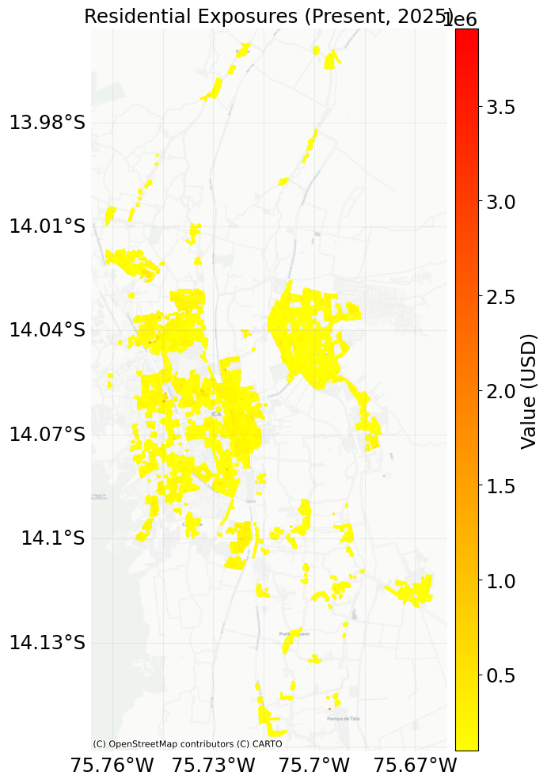

png

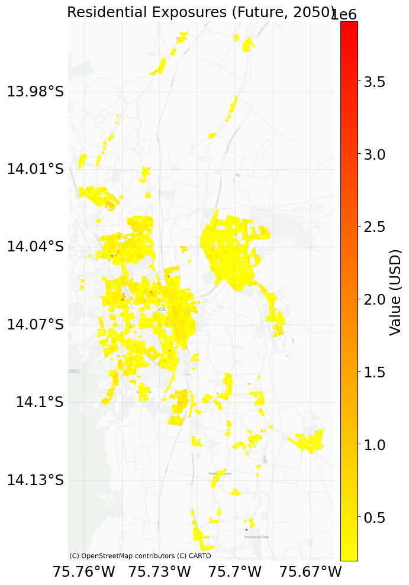

png

## 8.2 Create present-day and future Hazard objects

### 8.2.1 Read present-day hazard data

```python
from climada.hazard import Hazard

# Since we're reading hazard data from .tif files, we need to provide some additional metadata, including a frequency for each event
# As shown in the Hazard notebook, we have to convert return period frequencies to event frequencies:
RETURN_PERIODS_PRESENT = [10, 25, 50, 100, 200, 500]

def event_frequency_from_return_periods(return_periods):
    rp_rev = copy.deepcopy(return_periods)[::-1]  # Reverse the list so that it's in order of increasing frequency (decreasing return period)
    exceedance_frequency = np.array([1/rp for rp in rp_rev])
    event_frequency = np.diff(np.concatenate([[0], exceedance_frequency]))
    event_frequency = event_frequency[::-1]  # Reverse the frequencies so that they match the order of the events in the hazard file again
    return event_frequency

event_frequency = event_frequency_from_return_periods(RETURN_PERIODS_PRESENT)


# Read in the hazard data
haz_present = Hazard.from_raster(
    files_intensity = haz_filepaths,
    attrs={
        'unit': 'm',
        'event_name': [f'Return period {rp}' for rp in RETURN_PERIODS_PRESENT],     # We can optionally name the events
        'frequency': event_frequency                                         # For probabilistic analyses we have to define the frequency of each event
    },
    haz_type='FL'
)
```

```
2026-07-02 15:06:58,431 - climada.util.coordinates - INFO - Reading ../data/hazard/tr10_h_max_61200_4326.tif
2026-07-02 15:07:04,625 - climada.util.coordinates - INFO - Reading ../data/hazard/tr10_h_max_61200_4326.tif
2026-07-02 15:07:04,814 - climada.util.coordinates - INFO - Reading ../data/hazard/tr25_h_max_61200_4326.tif
2026-07-02 15:07:05,011 - climada.util.coordinates - INFO - Reading ../data/hazard/tr50_h_max_61200_4326.tif
2026-07-02 15:07:05,202 - climada.util.coordinates - INFO - Reading ../data/hazard/tr100_h_max_61200_4326.tif
2026-07-02 15:07:05,484 - climada.util.coordinates - INFO - Reading ../data/hazard/tr200_h_max_61200_4326.tif
2026-07-02 15:07:05,681 - climada.util.coordinates - INFO - Reading ../data/hazard/tr500_h_max_72000_4326.tif
```

```python
# Drop hazard centroids with zero hazard

# Unusually for a CLIMADA simulation, we want to remove locations with zero modelled hazard. This is because the flood simulation's very detailed DEM recognises the roofs of houses and doesn't model hazard at these locations.
# We solve this by removing centroids located within the housing polygons – and anywhere else that never experiences a hazard – we want rooftops to be _missing_ values rather than _zero_ values, forcing CLIMADA to use flood information from non-missing locations, i.e. the nearby streets.

intensity_threshold = 0.05       # 5 cm and less we'll ignore
ix = haz_present.intensity.max(axis=0) < intensity_threshold    # Use the hazard intensity matrix to identify centroids
assert ix.sum() > 0     # Ensure this hasn't removed all cpoints
ix = ix.todense().A1    # Convert from sparse matrix to 1D array of booleans
# Remove any grid cells with zero intensity across all events
haz_present.centroids.gdf["region_id"] = ix.astype(int)   # (bit hacky) set the hazard's centroid region IDs to 0 (centroid affected) or 1 (centroid never affected)
haz_present = haz_present.select(reg_id=0)  # Subset the Hazard to only include grid cells with non-zero intensity across all events
```

```
/usr/local/Caskroom/miniforge/base/envs/climada_env/lib/python3.11/site-packages/scipy/sparse/_base.py:463: SparseEfficiencyWarning: Comparing a sparse matrix with a scalar greater than zero using < is inefficient, try using >= instead.
  return self.tocsr().__lt__(other)
```

### 8.2.2 Create future Hazard data

When you specify future hazard information, you can do this by reading in a different dataset (e.g. with the output of future simulations), or by making adjustments to the present-day hazard.

Since we don’t have high-resolution future flood simulations for Ica from the model that produced our present-day hazard information, we will adjust the present-day hazard.

We do this by changing the Hazard object’s frequency information, making each event more (or less) likely to happen in a given year in the future climate. (We don’t recommend adjusting the hazard intensities: this is harder to estimate well and often results in unphysical flood footprints.)

Since we are working with return-period footprints, we will map present-day return periods to projected future return periods, and recalculate the event frequencies after this mapping.

**Note:** here we apply a simple adjustment that roughly doubles the frequency of all flood events. We recommend using information from the literature on heavy precipitation or flood frequency changes in the region to produce better estimates.

```python
# -------------------------------
# Read in return period mappings
# -------------------------------

rp_mapping_df = pd.read_csv(RP_MAPPING_FILEPATH)

assert np.array_equal(
        RETURN_PERIODS_PRESENT,
        rp_mapping_df["present_return_period"].values
    ), "RP mapping table must contain the same present-day return periods as the hazard files."

display(rp_mapping_df)
```

|  | present_depth_map | present_return_period | future_return_period_2050 | interpretation | present_frequency | future_frequency_2050 |
| --- | --- | --- | --- | --- | --- | --- |
| 0 | HIST_RP_10 | 10 | 5 | Present RP10 depth becomes future RP5 | 0.100 | 0.200 |
| 1 | HIST_RP_20 | 25 | 10 | Present RP20 depth becomes future RP10 | 0.050 | 0.100 |
| 2 | HIST_RP_50 | 50 | 20 | Present RP50 depth becomes future RP20 | 0.020 | 0.050 |
| 3 | HIST_RP_100 | 100 | 50 | Present RP100 depth becomes future RP50 | 0.010 | 0.020 |
| 4 | HIST_RP_200 | 200 | 100 | Present RP200 depth becomes future RP100 | 0.005 | 0.010 |
| 5 | HIST_RP_500 | 500 | 200 | Present RP500 depth becomes future RP200 | 0.002 | 0.005 |

```python
# -------------------------------
# Create a future hazard by changing present-day return periods
# -------------------------------

return_periods_future = rp_mapping_df["future_return_period_2050"].values

haz_future = copy.deepcopy(haz_present)
haz_future.frequency = event_frequency_from_return_periods(return_periods_future)
haz_future.event_name = [f'Return period {rp}' for rp in return_periods_future]

print("Future shifted hazard created")
print("Present return periods:", RETURN_PERIODS_PRESENT)
print("Future return periods:", return_periods_future)
print("Present event frequencies:", haz_present.frequency)
print("Future event frequencies:", haz_future.frequency)
```

```
Future shifted hazard created
Present return periods: [10, 25, 50, 100, 200, 500]
Future return periods: [  5  10  20  50 100 200]
Present event frequencies: [0.06  0.02  0.01  0.005 0.003 0.002]
Future event frequencies: [0.1   0.05  0.03  0.01  0.005 0.005]
```

```python
# ------------------------------------------
# Assign hazard centroids to the exposures
# ------------------------------------------

# See the 04_uncalibrated_risk.ipynb notebook for how we chose this threshold
# This must be done before any impact calculations, whether through ImpactCalc or CostBenefit
dist_threshold = 0.0002

entity_present.exposures.assign_centroids(haz_present, threshold=dist_threshold, overwrite=True)
entity_future.exposures.assign_centroids(haz_future, threshold=dist_threshold, overwrite=True)
```

```
2026-07-02 15:07:08,243 - climada.entity.exposures.base - INFO - Matching 107016 exposures with 282071 centroids.
2026-07-02 15:07:08,764 - climada.util.coordinates - INFO - No exact centroid match found. Reprojecting coordinates to nearest neighbor closer than the threshold = 0.0002 degree
2026-07-02 15:07:09,712 - climada.util.coordinates - WARNING - Distance to closest centroid is greater than 0.000200 degree for 99557 coordinates.
2026-07-02 15:07:09,722 - climada.entity.exposures.base - INFO - Matching 107016 exposures with 282071 centroids.
2026-07-02 15:07:10,141 - climada.util.coordinates - INFO - No exact centroid match found. Reprojecting coordinates to nearest neighbor closer than the threshold = 0.0002 degree
2026-07-02 15:07:11,060 - climada.util.coordinates - WARNING - Distance to closest centroid is greater than 0.000200 degree for 99557 coordinates.
```

## 8.3 Show components of changing risk in a waterfall plot

One of the most useful visualizations for how modelled risk changes between present-day and future climates is the waterfall plot. It breaks down the change into change driven by growth, and change from climate change. In the calculation, that means change from the future Entity and change from the future Hazard objects.

The plot is generated from the `CostBenefit.plot_waterfall` method (but doesn’t use Measures). We look at the other parts of a cost-benefit analysis in a later notebook.

```python
from climada.engine import CostBenefit

cb = CostBenefit()

ax = cb.plot_waterfall(
    haz_present,
    entity_present,
    haz_future,
    entity_future
)
ax = ax.set_title("Ica: Annual Expected Residential Flood Reconstruction Costs")
```

```
2026-07-02 15:07:11,139 - climada.engine.impact_calc - INFO - Calculating impact for 29925 assets (>0) and 6 events.
2026-07-02 15:07:11,194 - climada.engine.impact_calc - INFO - Calculating impact for 29925 assets (>0) and 6 events.
2026-07-02 15:07:11,253 - climada.engine.cost_benefit - INFO - Risk at 2025: 5.597e+05
2026-07-02 15:07:11,267 - climada.engine.impact_calc - INFO - Calculating impact for 29925 assets (>0) and 6 events.
2026-07-02 15:07:11,312 - climada.engine.cost_benefit - INFO - Risk with development at 2050: 1.123e+06
2026-07-02 15:07:11,312 - climada.engine.cost_benefit - INFO - Risk with development and climate change at 2050: 2.540e+06
```

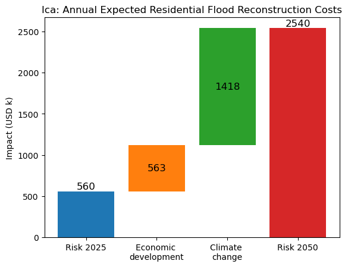

png

The three components of the average annual risk shown in the plot come from three Impact calculations run by CLIMADA:

- Baseline risk (present-day Hazard and present-day Entity)
- Economic development (calculating the difference from baseline to risk with present-day Hazard and future Entity)
- Economic development + climate change (calculating the difference from only economic change to risk with future Hazard and future Entity)

Note that the ‘climate change’ component is applied *on top of* the economic growth.

In this plot we see that

- The risk roughly doubles due to growth. This makes sense, as we scaled our Exposures by roughly a factor of two to create the future Entity
- The risk more than doubles again due to climate change. Again, this makes sense since our adjustment to event frequencies roughly doubled them.

Later in this notebook we will create a more detailed version of the plot.

## 8.4 Compare present-day and future risk

We can compare the changes in modelled risk by calculating the Impacts for present and future climates.

```python
from climada.engine import ImpactCalc

# ------------------------------------------
# Run impact calculations for present and future scenarios
# ------------------------------------------

impact_present = ImpactCalc(
    entity_present.exposures,
    entity_present.impact_funcs,
    haz_present
).impact(
    save_mat=True,
    assign_centroids=False,
    ignore_cover=True,
    ignore_deductible=True
)

impact_future = ImpactCalc(
    entity_future.exposures,
    entity_future.impact_funcs,
    haz_future
).impact(
    save_mat=True,
    assign_centroids=False,
    ignore_cover=True,
    ignore_deductible=True
)

print(f"Present-day annual expected flood impact: {impact_present.aai_agg:,.0f} USD")
print(f"Future annual expected flood impact: {impact_future.aai_agg:,.0f} USD")
```

```
2026-07-02 15:07:11,468 - climada.engine.impact_calc - INFO - Calculating impact for 17955 assets (>0) and 6 events.
2026-07-02 15:07:11,526 - climada.engine.impact_calc - INFO - Calculating impact for 17955 assets (>0) and 6 events.
Present-day annual expected flood impact: 559,693 USD
Future annual expected flood impact: 2,540,387 USD
```

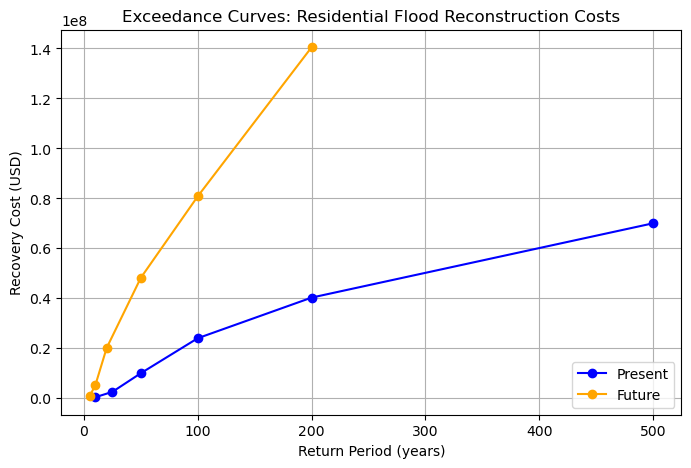

png

```python
import matplotlib.pyplot as plt

# ---------------------------
# Compare Exceedance curves
# ---------------------------

exceedance_present = impact_present.calc_freq_curve()
exceedance_future = impact_future.calc_freq_curve()

fig, axis = plt.subplots(figsize=(8, 5))
exceedance_present.plot(axis=axis, color="blue", marker="o", label="Present")
exceedance_future.plot(axis=axis, color="orange", marker="o", label="Future")
axis.set_title("Exceedance Curves: Residential Flood Reconstruction Costs")
axis.set_xlabel("Return Period (years)")
axis.set_ylabel("Recovery Cost (USD)")
plt.grid(True)
axis.legend(loc="lower right")
plt.show()
plt.close(axis.figure)
```

This plot summarizes the dramatic changes from combined economic growth (effectively scaling along the y-axis) and climate change (making rare events more frequent). The future exceedance curve is dramatically higher than the present-day exceedance.

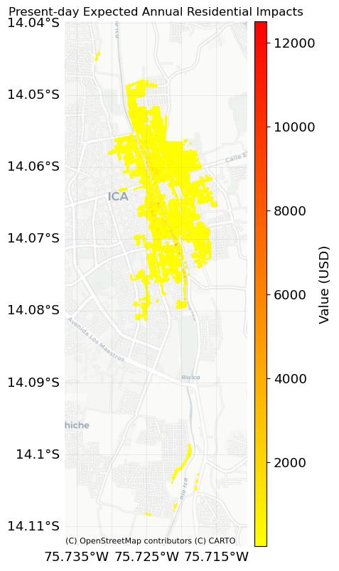

png

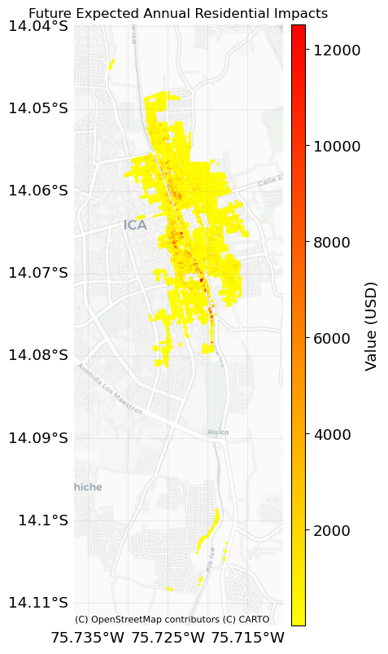

png

```python
import contextily as ctx

# ----------------------------
# Map expected annual impacts
# ----------------------------

max_impact = impact_future.eai_exp.max()

axis = impact_present.plot_basemap_eai_exposure(
    ignore_zero=True,                   # Don't plot locations with zero impacts
    pop_name=False,                     # Don't plot place names
    buffer=500,                         # Add spatial buffers to the map (in the CRS coordinate units)
    s=2,                                # The size of point markers on the plot
    zoom=14,                            # Level of detail to add to the basemap
    cmap="autumn_r",                    # Colour scheme to use for the points. See https://matplotlib.org/stable/tutorials/colors/colormaps.html for options.
    vmax=max_impact,                    # Set the maximum value for the colour scale
    url=ctx.providers.CartoDB.Positron, # Basemap provider
    figsize=(6, 8)
)
axis.set_title(f"Present-day Expected Annual Residential Impacts")
plt.show()
plt.close(axis.figure)

axis = impact_future.plot_basemap_eai_exposure(
    ignore_zero=True,                   # Don't plot locations with zero impacts
    pop_name=False,                     # Don't plot place names
    buffer=500,                         # Add spatial buffers to the map (in the CRS coordinate units)
    s=2,                                # The size of point markers on the plot
    zoom=14,                            # Level of detail to add to the basemap
    cmap="autumn_r",                    # Colour scheme to use for the points. See https://matplotlib.org/stable/tutorials/colors/colormaps.html for options.
    vmax=max_impact,                    # Set the maximum value for the colour scale
    url=ctx.providers.CartoDB.Positron, # Basemap provider
    figsize=(6, 8)
)
axis.set_title(f"Future Expected Annual Residential Impacts")
plt.show()
plt.close(axis.figure)
```

### 8.4.1 Further exploration of the breakdown of risk

By running different Impact calculations, we can explore how changes to hazard and exposures drive changes in the risk calculation.

Here we show four risk calculations, each for different components of risk. (Some of these we did already but we show them again for completeness.). We can then summarize the results in a table and generate a more detailed waterfall plot.

```python
# 1. Present-day exposure + present-day hazard
impact_present_present = ImpactCalc(
    entity_present.exposures,
    entity_present.impact_funcs,
    haz_present
).impact(
    save_mat=True,
    assign_centroids=False,
    ignore_cover=True,
    ignore_deductible=True
)

# 2. Future exposure + present-day hazard
impact_future_exp_only = ImpactCalc(
    entity_future.exposures,
    entity_future.impact_funcs,
    haz_present
).impact(
    save_mat=True,
    assign_centroids=False,
    ignore_cover=True,
    ignore_deductible=True
)

# 3. Present-day exposure + future hazard
impact_future_haz_only = ImpactCalc(
    entity_present.exposures,
    entity_present.impact_funcs,
    haz_future
).impact(
    save_mat=True,
    assign_centroids=False,
    ignore_cover=True,
    ignore_deductible=True
)

# 4. Future exposure + future hazard
impact_future_combined = ImpactCalc(
    entity_future.exposures,
    entity_future.impact_funcs,
    haz_future
).impact(
    save_mat=True,
    assign_centroids=False,
    ignore_cover=True,
    ignore_deductible=True
)

decomp_df = pd.DataFrame({
    "Scenario": [
        "Present-day exposure + present-day hazard",
        "Future exposure + present-day hazard",
        "Present-day exposure + future hazard",
        "Future exposure + future hazard"
    ],
    "Average annual impact (USD)": [
        impact_present_present.aai_agg,
        impact_future_exp_only.aai_agg,
        impact_future_haz_only.aai_agg,
        impact_future_combined.aai_agg
    ]
})

decomp_df["% increase from baseline"] = (
    decomp_df["Average annual impact (USD)"]
    / decomp_df["Average annual impact (USD)"].iloc[0]
    - 1
) * 100

numeric_cols = decomp_df.select_dtypes(include="number").columns
display(
    decomp_df.style.format({
        "Average annual impact (USD)": "{:,.0f}",
        "% increase from baseline": "{:.2f}%"
    })
)
```

```
2026-07-02 15:07:15,154 - climada.engine.impact_calc - INFO - Calculating impact for 17955 assets (>0) and 6 events.
2026-07-02 15:07:15,220 - climada.engine.impact_calc - INFO - Calculating impact for 17955 assets (>0) and 6 events.
2026-07-02 15:07:15,277 - climada.engine.impact_calc - INFO - Calculating impact for 17955 assets (>0) and 6 events.
2026-07-02 15:07:15,331 - climada.engine.impact_calc - INFO - Calculating impact for 17955 assets (>0) and 6 events.
```

|  | Scenario | Average annual impact (USD) | % increase from baseline |
| --- | --- | --- | --- |
| 0 | Present-day exposure + present-day hazard | 559,693 | 0.00% |
| 1 | Future exposure + present-day hazard | 1,122,553 | 100.57% |
| 2 | Present-day exposure + future hazard | 1,266,610 | 126.30% |
| 3 | Future exposure + future hazard | 2,540,387 | 353.89% |

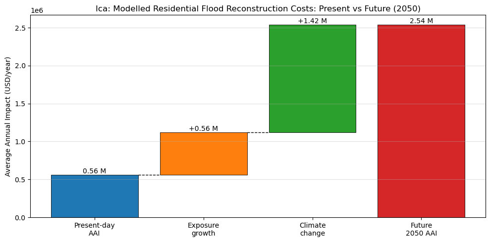

png

```python
# ---------------------------------------
# Create a more detailed waterfall plot
# ---------------------------------------

# Gather the data we need

baseline_aai = impact_present_present.aai_agg
exp_only_aai = impact_future_exp_only.aai_agg
combined_aai = impact_future_combined.aai_agg

exposure_growth_effect = exp_only_aai - baseline_aai
climate_change_effect = combined_aai - exp_only_aai

components = [
    "Present-day\nAAI",
    "Exposure\ngrowth",
    "Climate\nchange",
    "Future\n2050 AAI"
]

heights = [
    baseline_aai,
    exposure_growth_effect,
    climate_change_effect,
    combined_aai
]

bottoms = [
    0,
    baseline_aai,
    baseline_aai + exposure_growth_effect,
    0
]

colors = [
    "tab:blue",
    "tab:orange",
    "tab:green",
    "tab:red"
]

# Build the plot!

fig, ax = plt.subplots(figsize=(10, 5))

ax.bar(
    np.arange(len(components)),
    heights,
    bottom=bottoms,
    color=colors,
    edgecolor="black",
    linewidth=0.6
)

running_totals = [
    baseline_aai,
    baseline_aai + exposure_growth_effect,
    combined_aai
]

for i in range(len(running_totals) - 1):
    ax.plot(
        [i + 0.4, i + 1 - 0.4],
        [running_totals[i], running_totals[i]],
        color="black",
        linestyle="--",
        linewidth=1
    )

for i, (bottom, height) in enumerate(zip(bottoms, heights)):
    if i == 0 or i == len(components) - 1:
        label_y = height
        label_text = f"{height / 1e6:.2f} M"
    else:
        label_y = bottom + height
        label_text = f"+{height / 1e6:.2f} M"

    ax.text(
        i,
        label_y,
        label_text,
        ha="center",
        va="bottom",
        fontsize=10
    )

ax.set_xticks(np.arange(len(components)))
ax.set_xticklabels(components)
ax.set_ylabel("Average Annual Impact (USD/year)")
ax.set_title("Ica: Modelled Residential Flood Reconstruction Costs: Present vs Future (2050)")
ax.grid(axis="y", alpha=0.4)

plt.tight_layout()
plt.show()

waterfall_plot_df = pd.DataFrame({
    "component": [
        "Present-day AAI",
        "Exposure growth",
        "Climate change",
        "Future 2050 AAI"
    ],
    "value_usd": heights,
    "bottom_usd": bottoms
})
```

### 8.4.2 Extensions to this notebook

Note: this is a first version of the notebook. It should give you enough information to build and run your own future risk analyses.

There are still a few improvements to make to the data: - repeat the above analysis for ‘affected’ and ‘destroyed’ housing - use all three asset types - use of projected socioeconomic change information to estimate future asset values - more scientifically-grounded estimations of the changes of flood return periods under climate change